# Auxin-treated AID-Ogt MEFs Differential Expression analysis

Sara Formichetti

EMBL Rome  
sara.formichetti@embl.it

August 27, 2021

# 1 Design of the experiment

1. 3 biological replicates, each one composed of a pair of MEFs clones coming from the same litter
2. For each biological replicate, each pair of clones is composed of:
- an OsTIR1-only clone, which expresses OsTIR1 but not the AID-Ogt isoform, thus auxin treatment is not supposed to cause any OGT depletion. This clone represents the control of the corresponding biological replicate
- an AID-Ogt;OsTIR clone, which bears both genomic modifications necessary to obtain OGT depletion after auxin treatment.
3. All clones (both controls and AID-Ogt;OsTIR clones) were collected in the following conditions:
- without any auxin addition (No auxin)
- after 24h of auxin treatment
- after 48h of auxin treatment
- after 4 days of auxin treatment.

# 2 PCA

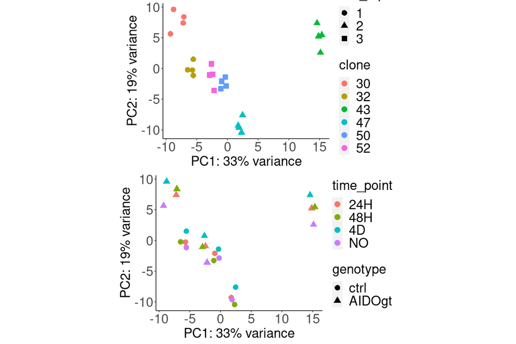

The main factor separating the samples is the cell clone and clone’s litter (biological replicate) on PC1, then the condition dominates ordering along PC2 inside each clone’s cluster.

# 3 Plotting counts for Ogt, Oga, OsTIR

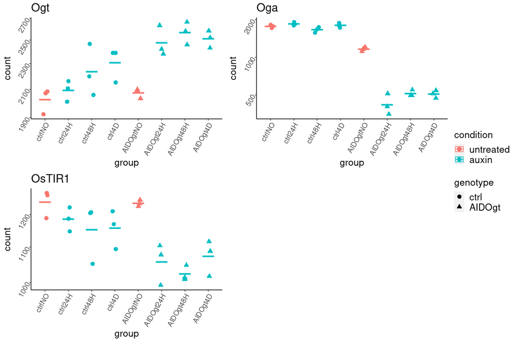

# 4 Diff Expr Analysis

## 4.1 P-value histograms and MA-plots for the different comparisons

The threshold used for a dot to be colored in blue in the MA-plots is: p-value adjusted < 0.05.

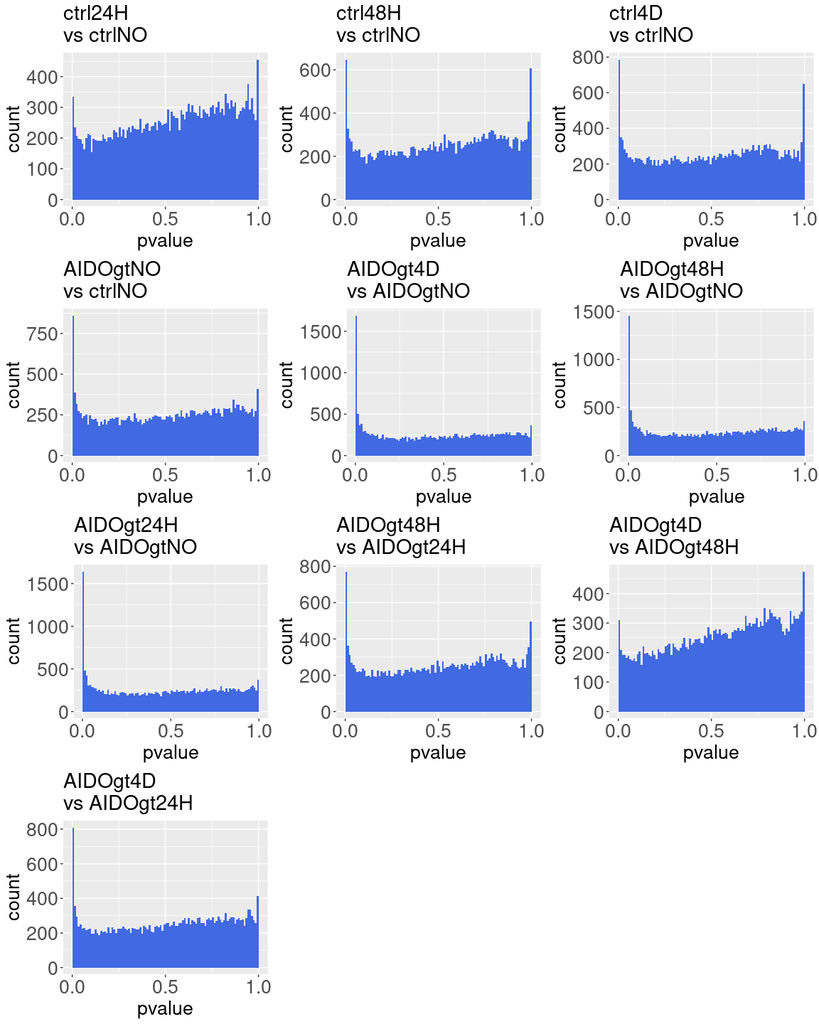

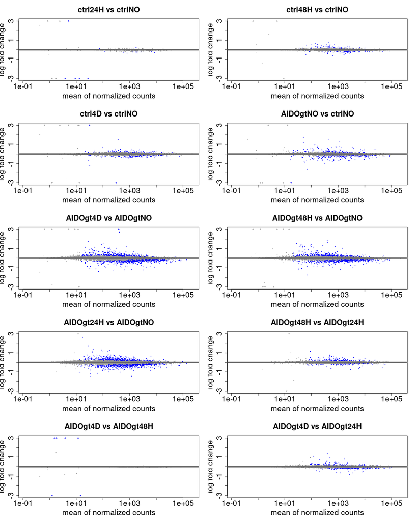

## 4.2 Volcano plots for the different comparisons

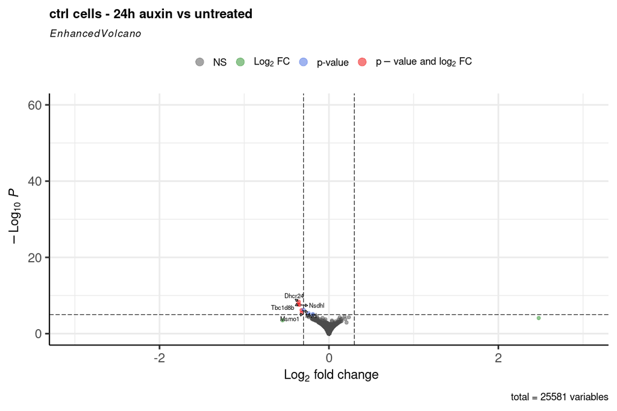

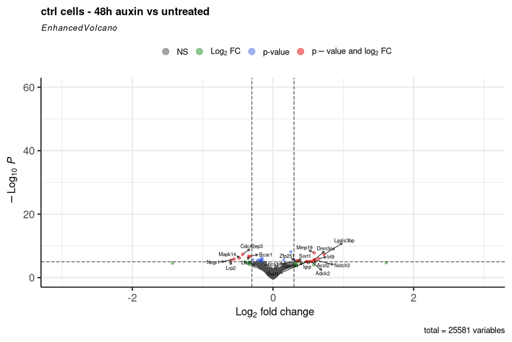

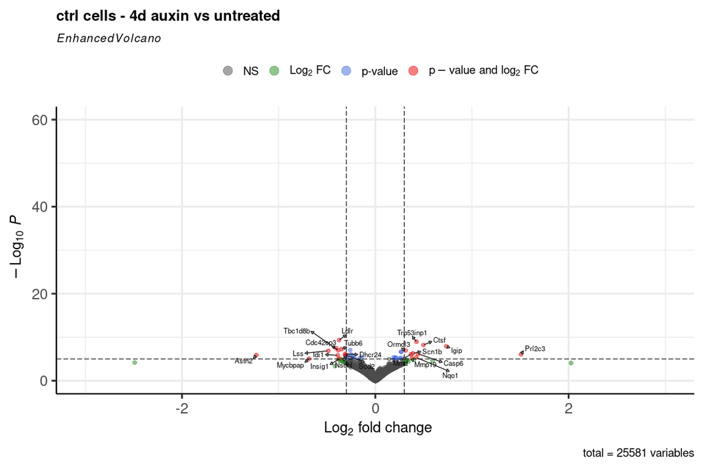

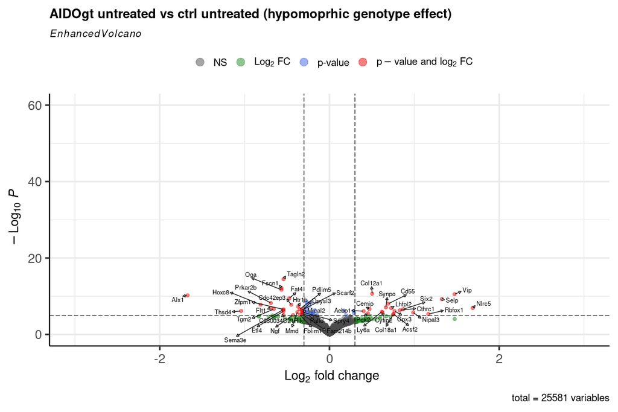

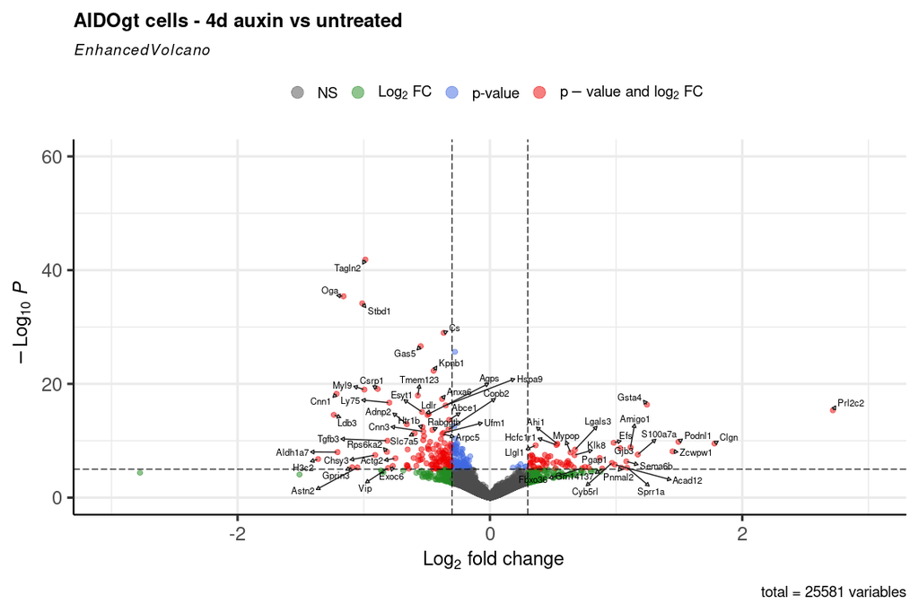

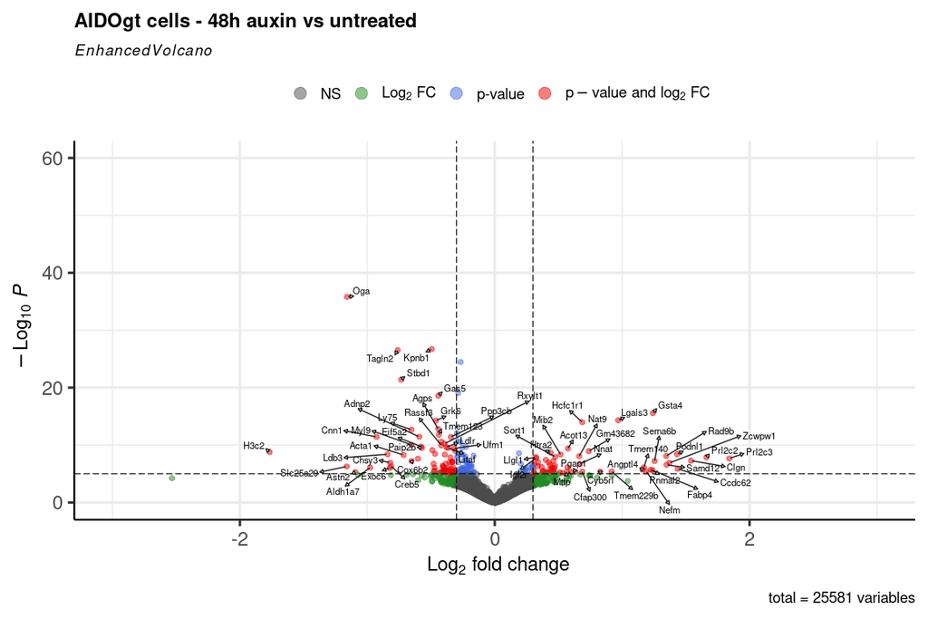

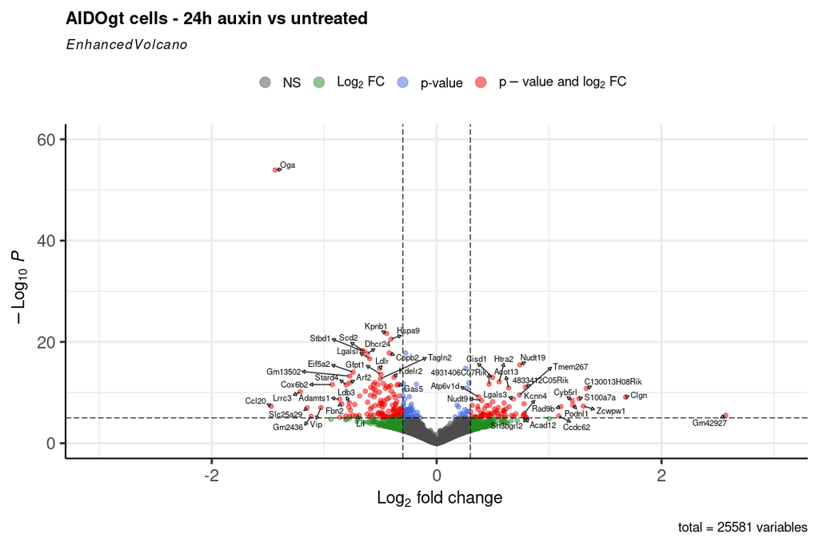

```r
library(EnhancedVolcano)

volcano_plot <- function (i, my_res_list) {
  res_names <- retrieve_res_names(my_res_list[[i]])
  EnhancedVolcano(my_res_list[[i]], lab = res_names$gene_name, x = 'log2FoldChange', y = 'pvalue', xlim = c(-3,3), ylim = c(0,60),
                  FCcutoff = 0.3,
                  title = names(my_res_list)[i],
                  labSize = 3,
                  max.overlaps = 30,
                  drawConnectors = TRUE)
}

lapply(1:7, volcano_plot, my_res_list = my_res_list)
```

## 4.3 Getting DE genes, ordered by p-value

Getting the DE genes (padj < 0.05, any log2FC), ordered by pvalue.

## 4.4 DE genes over-representation tests

I use the DE genes observed in AID cells after 24h/48h/4d of auxin treatment (compared to the NO auxin condition), after exclusion of the DE genes observed by treating ctrl cells with auxin at any of the three time points.

### 4.4.1 Overlap between groups of DEGs

Overlap of DEGs due to OGT depletion with DEGs due to auxin effect on ctrl cells:

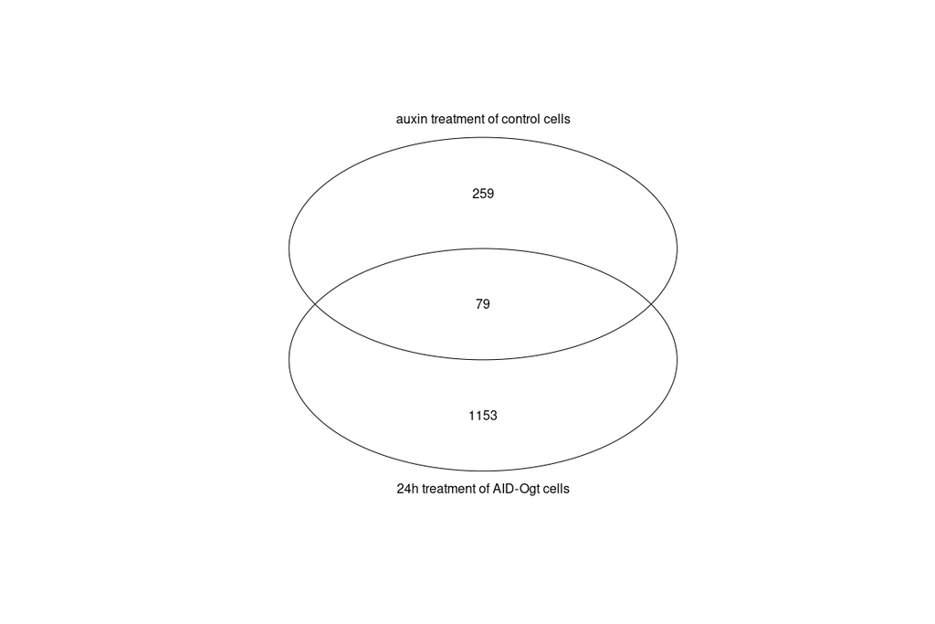

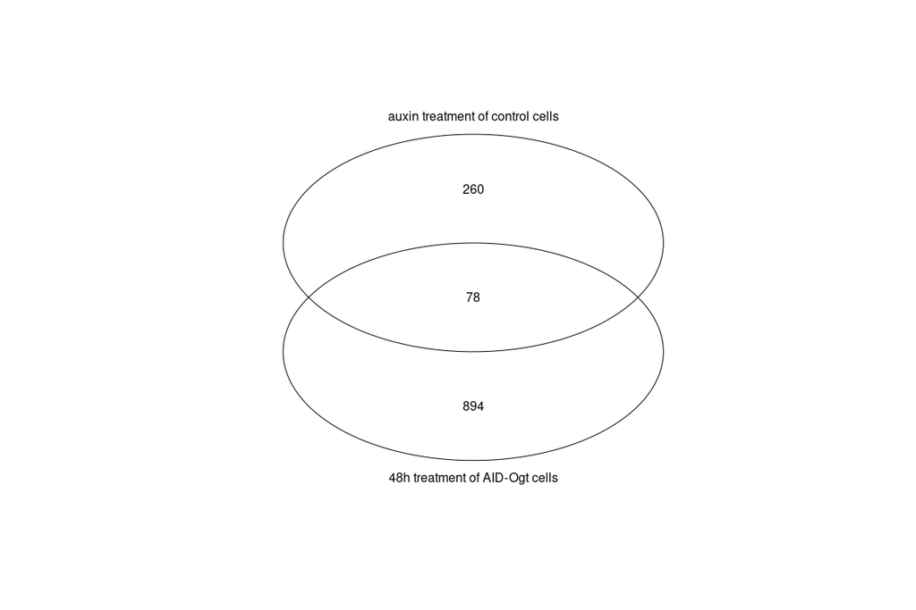

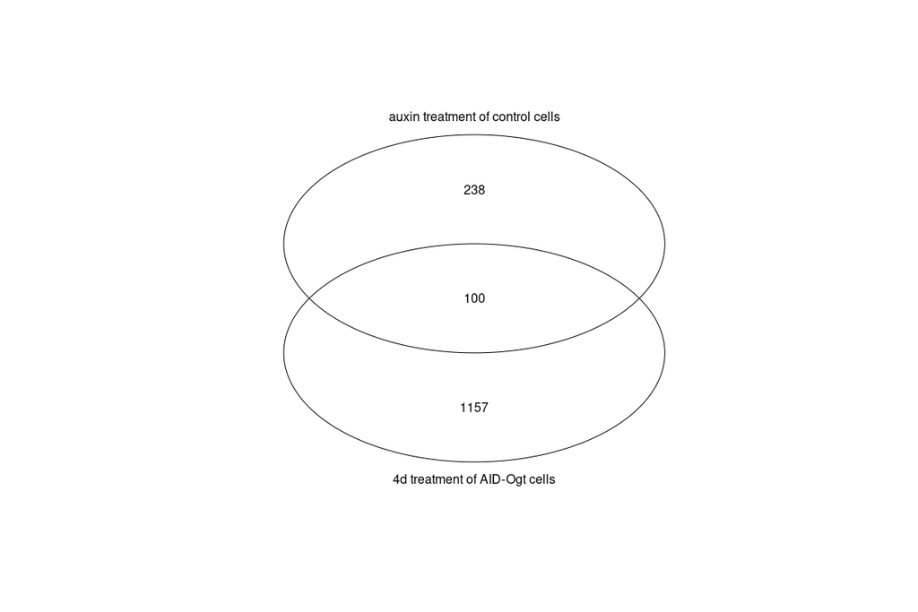

Overlap of DEGs at different time points of OGT depletion (auxin effect’s DEGs were excluded):

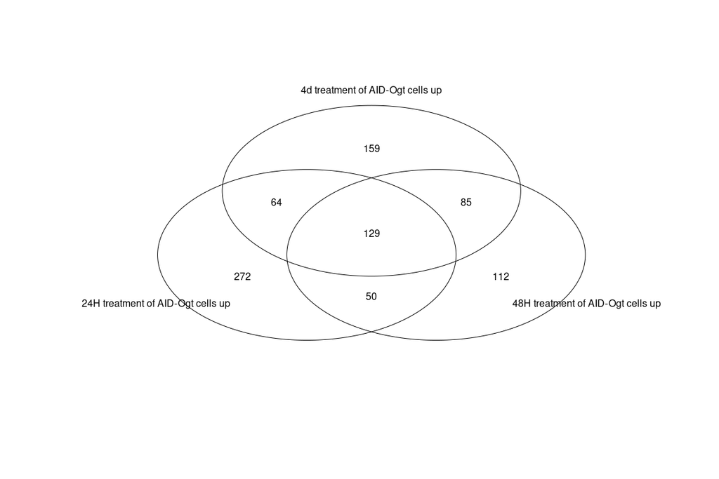

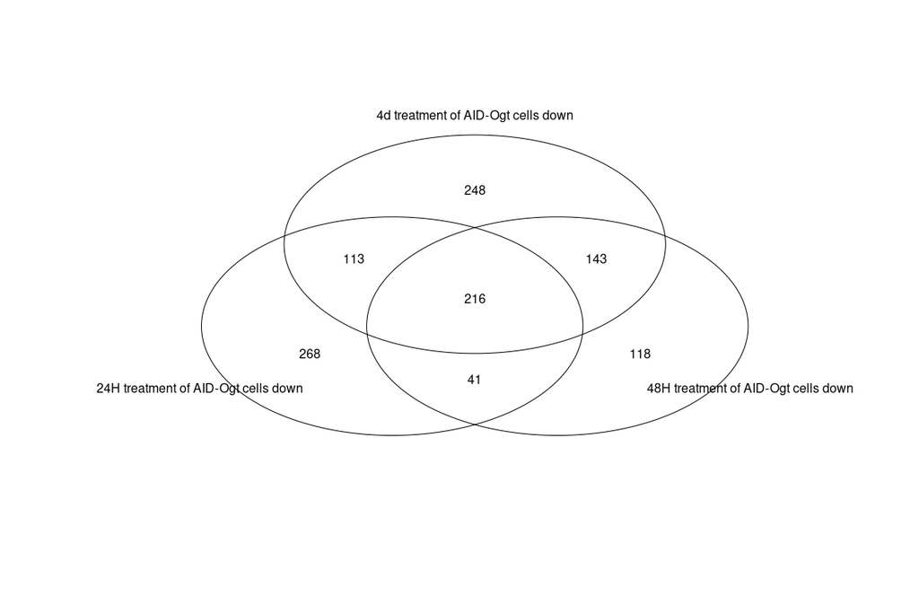

Pvalues of overlaps for upregulated DEGs are:

- 6.1496325^{-166} for AID-Ogt 24h aux & AID-Ogt 48h aux, both w/o auxin-effect genes
- 4.5697982^{-172} for AID-Ogt 24h aux & AID-Ogt 4d aux, both w/o auxin-effect genes
- 1.3717679^{-244} for AID-Ogt 48h aux & AID-Ogt 4d aux, both w/o auxin-effect genes
- 6.9704315^{-13} for AID-Ogt 4d aux & 4d aux on ctrl cells

Pvalues of overlaps for downregulated DEGs are:

- 7.3400989^{-224} for AID-Ogt 24h aux & AID-Ogt 48h aux, both w/o auxin-effect genes
- 1.9600784^{-281} for AID-Ogt 24h aux & AID-Ogt 4d aux, both w/o auxin-effect genes
- 0 for AID-Ogt 48h aux & AID-Ogt 4d aux, both w/o auxin-effect genes
- 0.9786367 for AID-Ogt 4d aux & 4d aux on ctrl cells

Note that:

- pval decreases for with longer treatment –> effects at 48h and 4d time points are more similar between each other than to the 24h time point
- the pval is much higher when comparing 4d-treated AID-Ogt cells and 4d-treated control cells.

### 4.4.2 Gene Ontology Over-representation Test - up and downregulated genes separately

genotype effect - BP up

| ID | Description | GeneRatio | BgRatio | pvalue | p.adjust | qvalue | geneID | Count |
| --- | --- | --- | --- | --- | --- | --- | --- | --- |

genotype effect - CC up

| ID | Description | GeneRatio | BgRatio | pvalue | p.adjust | qvalue | geneID | Count |
| --- | --- | --- | --- | --- | --- | --- | --- | --- |

genotype effect - MF up

| ID | Description | GeneRatio | BgRatio | pvalue | p.adjust | qvalue | geneID | Count |
| --- | --- | --- | --- | --- | --- | --- | --- | --- |

24h auxin on AID-Ogt cells - BP up

|  | ID | Description | GeneRatio | BgRatio | pvalue | p.adjust | qvalue | geneID | Count |
| --- | --- | --- | --- | --- | --- | --- | --- | --- | --- |
| GO:0022613 | GO:0022613 | ribonucleoprotein complex biogenesis | 22/472 | 411/22853 | 0.0000514 | 0.0208542 | 0.0199494 | Mrps7/Rrp15/Las1l/Gemin6/Ddx17/Bms1/LTO1/Gemin4/Frg1/Bysl/Emg1/Ddx51/Zfp622/Nvl/Npm3/Rpusd3/Rpusd1/Snu13/Xab2/Ncbp1/Exosc5/Crnkl1 | 22 |
| GO:0044270 | GO:0044270 | cellular nitrogen compound catabolic process | 21/472 | 412/22853 | 0.0001499 | 0.0395218 | 0.0378071 | Nudt19/Nudt9/Nit1/Rida/Apex1/E2f1/Phax/Dctpp1/Zfp36l2/Fastkd1/Vim/Hmox1/Rnaseh2a/Pde12/Entpd5/Hint1/Smg8/Tymp/Ncbp1/Rbm8a/Exosc5 | 21 |
| GO:0051099 | GO:0051099 | positive regulation of binding | 13/472 | 194/22853 | 0.0002098 | 0.0465691 | 0.0445487 | Ngf/Nme1/Ripor2/Ramp1/Eif2b4/Anxa2/Eif2b1/S100a10/Psen1/Nvl/Smarca4/Ncbp1/Pparg | 13 |

24h auxin on AID-Ogt cells - CC up

|  | ID | Description | GeneRatio | BgRatio | pvalue | p.adjust | qvalue | geneID | Count |
| --- | --- | --- | --- | --- | --- | --- | --- | --- | --- |
| GO:0098798 | GO:0098798 | mitochondrial protein-containing complex | 22/486 | 260/22838 | 0.00e+00 | 0.0000210 | 0.0000182 | Tomm22/Bckdha/Mrpl34/Mrps7/Mrpl42/Chchd6/Ndufb10/Mrps21/Mrps6/Uqcc3/Mrpl33/Mrpl45/Cox5a/Mrpl35/Chchd3/Mrpl38/Mrpl28/Mrpl17/Ndufb9/Mrps22/Ndufs7/Micos13 | 22 |
| GO:1905369 | GO:1905369 | endopeptidase complex | 10/486 | 70/22838 | 2.20e-06 | 0.0001674 | 0.0001453 | Htra2/Psmb7/Psmb1/Psmd4/Psma7/Psmb5/Psma4/Psmc2/Hspb1/Ecpas | 10 |
| GO:0000315 | GO:0000315 | organellar large ribosomal subunit | 8/486 | 58/22838 | 2.99e-05 | 0.0015193 | 0.0013193 | Mrpl34/Mrpl42/Mrpl33/Mrpl45/Mrpl35/Mrpl38/Mrpl28/Mrpl17 | 8 |
| GO:0005839 | GO:0005839 | proteasome core complex | 5/486 | 19/22838 | 3.88e-05 | 0.0017750 | 0.0015413 | Psmb7/Psmb1/Psma7/Psmb5/Psma4 | 5 |
| GO:0098573 | GO:0098573 | intrinsic component of mitochondrial membrane | 9/486 | 81/22838 | 5.58e-05 | 0.0019612 | 0.0017030 | Chchd6/Slc25a19/Synj2bp/Uqcc3/Coa3/Cox18/Adck1/Chchd3/Micos13 | 9 |

24h auxin on AID-Ogt cells - MF up

|  | ID | Description | GeneRatio | BgRatio | pvalue | p.adjust | qvalue | geneID | Count |
| --- | --- | --- | --- | --- | --- | --- | --- | --- | --- |
| GO:0003906 | GO:0003906 | DNA-(apurinic or apyrimidinic site) endonuclease activity | 4/472 | 13/22360 | 0.0001205 | 0.0403050 | 0.0356067 | Hmga1b/Apex1/Nthl1/Hmga2 | 4 |
| GO:0070003 | GO:0070003 | threonine-type peptidase activity | 4/472 | 19/22360 | 0.0005907 | 0.0429728 | 0.0379635 | Psmb7/Psmb1/Psmb5/Psma4 | 4 |

48h auxin on AID-Ogt cells - BP up

| ID | Description | GeneRatio | BgRatio | pvalue | p.adjust | qvalue | geneID | Count |
| --- | --- | --- | --- | --- | --- | --- | --- | --- |

48h auxin on AID-Ogt cells - CC up

| ID | Description | GeneRatio | BgRatio | pvalue | p.adjust | qvalue | geneID | Count |
| --- | --- | --- | --- | --- | --- | --- | --- | --- |

48h auxin on AID-Ogt cells - MF up

| ID | Description | GeneRatio | BgRatio | pvalue | p.adjust | qvalue | geneID | Count |
| --- | --- | --- | --- | --- | --- | --- | --- | --- |

4d auxin on AID-Ogt cells - BP up

| ID | Description | GeneRatio | BgRatio | pvalue | p.adjust | qvalue | geneID | Count |
| --- | --- | --- | --- | --- | --- | --- | --- | --- |

4d auxin on AID-Ogt cells - CC up

|  | ID | Description | GeneRatio | BgRatio | pvalue | p.adjust | qvalue | geneID | Count |
| --- | --- | --- | --- | --- | --- | --- | --- | --- | --- |
| GO:0005774 | GO:0005774 | vacuolar membrane | 13/410 | 226/22838 | 0.0002405 | 0.0359122 | 0.0328239 | Pld3/Mcoln1/Abcd4/Vps13a/Npc1/Cyb561a3/Atg16l2/Stx8/Slc48a1/Nprl2/Gpr137b/Vamp8/H2-M3 | 13 |

4d auxin on AID-Ogt cells - MF up

| ID | Description | GeneRatio | BgRatio | pvalue | p.adjust | qvalue | geneID | Count |
| --- | --- | --- | --- | --- | --- | --- | --- | --- |

4d auxin on ctrl cells - BP up

| ID | Description | GeneRatio | BgRatio | pvalue | p.adjust | qvalue | geneID | Count |
| --- | --- | --- | --- | --- | --- | --- | --- | --- |

4d auxin on ctrl cells - CC up

| ID | Description | GeneRatio | BgRatio | pvalue | p.adjust | qvalue | geneID | Count |
| --- | --- | --- | --- | --- | --- | --- | --- | --- |

4d auxin on ctrl cells - MF up

| ID | Description | GeneRatio | BgRatio | pvalue | p.adjust | qvalue | geneID | Count |
| --- | --- | --- | --- | --- | --- | --- | --- | --- |

genotype effect - BP down

|  | ID | Description | GeneRatio | BgRatio | pvalue | p.adjust | qvalue | geneID | Count |
| --- | --- | --- | --- | --- | --- | --- | --- | --- | --- |
| GO:0007015 | GO:0007015 | actin filament organization | 25/189 | 456/22853 | 0.0000000 | 0.0000000 | 0.0000000 | Fscn1/Pfn1/Cdc42ep3/Dpysl3/Cfl1/Mical2/Arpc5/Cfl2/Actg1/Fermt2/Tmsb4x/Acta1/Cdc42ep1/Srf/Tnfaip1/Tnnt2/Arhgef5/Vasp/Sorbs2/Capzb/Myo1c/Arpc4/Tmsb10/Pawr/Swap70 | 25 |
| GO:0032970 | GO:0032970 | regulation of actin filament-based process | 22/189 | 417/22853 | 0.0000000 | 0.0000000 | 0.0000000 | Fscn1/Pfn1/Cdc42ep3/Sema3e/Cfl1/Arpc5/Cfl2/Epha3/Actg1/Fermt2/Tmsb4x/Cdc42ep1/Tnnt2/Ilk/Arhgef5/Vasp/Capzb/Myo1c/Arpc4/Tmsb10/Cnn2/Swap70 | 22 |
| GO:0032535 | GO:0032535 | regulation of cellular component size | 20/189 | 417/22853 | 0.0000000 | 0.0000002 | 0.0000002 | Pfn1/Cdc42ep3/Sema3e/Cfl1/Arpc5/Cfl2/Ngf/Rab3b/Tmsb4x/Cdc42ep1/Srf/Ilk/Vasp/Capzb/Myo1c/Chmp3/Akt1/Arpc4/Tmsb10/Swap70 | 20 |
| GO:0042692 | GO:0042692 | muscle cell differentiation | 18/189 | 426/22853 | 0.0000000 | 0.0000059 | 0.0000048 | Pdlim5/Cfl2/Actg1/Csrp1/Tmsb4x/Acta1/Tbx2/Hacd1/Srf/Tnnt2/Igf2/Fhl2/Hdac5/Sorbs2/Capzb/Mapk14/Homer1/Akt1 | 18 |
| GO:1902903 | GO:1902903 | regulation of supramolecular fiber organization | 16/189 | 389/22853 | 0.0000002 | 0.0000407 | 0.0000334 | Pfn1/Cdc42ep3/Cfl1/Arpc5/Cfl2/Actg1/Fermt2/Tmsb4x/Cdc42ep1/Arhgef5/Vasp/Capzb/Myo1c/Arpc4/Tmsb10/Swap70 | 16 |
| GO:0010810 | GO:0010810 | regulation of cell-substrate adhesion | 12/189 | 226/22853 | 0.0000004 | 0.0000664 | 0.0000545 | Sema3e/Cfl1/Spry4/Epha3/Actg1/Fermt2/Hacd1/Peak1/Ilk/Rras/Itga5/Itga3 | 12 |
| GO:0043254 | GO:0043254 | regulation of protein-containing complex assembly | 16/189 | 452/22853 | 0.0000012 | 0.0001705 | 0.0001400 | Fscn1/Pfn1/Cdc42ep3/Cfl1/Arpc5/Fblim1/Fermt2/Tmsb4x/Cdc42ep1/Arhgef5/Vasp/Capzb/Myo1c/Raf1/Arpc4/Tmsb10 | 16 |
| GO:0007264 | GO:0007264 | small GTPase mediated signal transduction | 15/189 | 425/22853 | 0.0000027 | 0.0003517 | 0.0002887 | Cdc42ep3/Spry4/Rassf1/Ngf/Ppp2cb/Ywhaq/F2r/Cdc42ep1/Rasgrp2/Tnfaip1/Adcyap1r1/Garre1/Rras/Itga3/Dock8 | 15 |
| GO:0001667 | GO:0001667 | ameboidal-type cell migration | 15/189 | 442/22853 | 0.0000044 | 0.0005211 | 0.0004278 | Alx1/Pfn1/Sema3e/Cfl1/Clec14a/Srf/Igf2/Ilk/Hdac5/Gpi1/Cap1/Rras/Gdf6/Akt1/Itga3 | 15 |
| GO:0060562 | GO:0060562 | epithelial tube morphogenesis | 14/189 | 391/22853 | 0.0000051 | 0.0005730 | 0.0004704 | Alx1/Fat4/Pfn1/Flt1/Sema3e/Cfl1/Hmga2/Foxd1/Tbx2/Srf/Ilk/Hdac5/Vasp/Ppp1ca | 14 |
| GO:0060537 | GO:0060537 | muscle tissue development | 15/189 | 482/22853 | 0.0000124 | 0.0013049 | 0.0010711 | Ybx3/Pdlim5/Zfpm1/Cfl2/Csrp1/Acta1/Tbx2/Srf/Tnnt2/Igf2/Fhl2/Hdac5/Sorbs2/Mapk14/Homer1 | 15 |
| GO:0045927 | GO:0045927 | positive regulation of growth | 12/189 | 320/22853 | 0.0000154 | 0.0015133 | 0.0012422 | Ybx3/Cfl1/Ngf/Hmga2/Rftn1/Tbx2/Srf/Igf2/Ilk/Avpr1a/Mapk14/Akt1 | 12 |
| GO:0090398 | GO:0090398 | cellular senescence | 6/189 | 67/22853 | 0.0000194 | 0.0017098 | 0.0014035 | Hmga2/Hmga1b/Tbx2/Srf/Mapk14/Pawr | 6 |
| GO:0030239 | GO:0030239 | myofibril assembly | 6/189 | 69/22853 | 0.0000230 | 0.0018792 | 0.0015425 | Cfl2/Actg1/Csrp1/Acta1/Srf/Tnnt2 | 6 |
| GO:0060485 | GO:0060485 | mesenchyme development | 11/189 | 292/22853 | 0.0000337 | 0.0026078 | 0.0021406 | Alx1/Sema3e/Cfl1/Tgfb1i1/Epha3/Pax1/Hmga2/Fermt2/Foxd1/Tbx2/Pawr | 11 |
| GO:0002040 | GO:0002040 | sprouting angiogenesis | 7/189 | 123/22853 | 0.0000750 | 0.0045022 | 0.0036957 | Flt1/Sema3e/Clec14a/Srf/Hdac5/Akt1/Itga5 | 7 |
| GO:0001649 | GO:0001649 | osteoblast differentiation | 9/189 | 220/22853 | 0.0000944 | 0.0053421 | 0.0043851 | Fermt2/Cebpa/Igf2/Ilk/Fhl2/Hdac5/Mapk14/Akt1/Pdlim7 | 9 |
| GO:0007160 | GO:0007160 | cell-matrix adhesion | 9/189 | 225/22853 | 0.0001120 | 0.0061020 | 0.0050088 | Sema3e/Cfl1/Epha3/Actg1/Fermt2/Srf/Peak1/Ilk/Rras | 9 |
| GO:0042989 | GO:0042989 | sequestering of actin monomers | 3/189 | 12/22853 | 0.0001159 | 0.0062035 | 0.0050922 | Pfn1/Tmsb4x/Tmsb10 | 3 |
| GO:2000648 | GO:2000648 | positive regulation of stem cell proliferation | 4/189 | 31/22853 | 0.0001197 | 0.0062632 | 0.0051412 | Ngf/Hmga2/Fermt2/Hdac5 | 4 |
| GO:0022604 | GO:0022604 | regulation of cell morphogenesis | 11/189 | 337/22853 | 0.0001213 | 0.0062632 | 0.0051412 | Cdc42ep3/Aldoa/Sema3e/Cfl1/Myl12a/Spry4/Fblim1/Fermt2/Cdc42ep1/Ilk/Capzb | 11 |
| GO:2000774 | GO:2000774 | positive regulation of cellular senescence | 3/189 | 13/22853 | 0.0001498 | 0.0069977 | 0.0057441 | Hmga2/Hmga1b/Pawr | 3 |
| GO:0043243 | GO:0043243 | positive regulation of protein-containing complex disassembly | 4/189 | 35/22853 | 0.0001942 | 0.0081627 | 0.0067004 | Oga/Cfl1/Cfl2/Nes | 4 |
| GO:0043954 | GO:0043954 | cellular component maintenance | 5/189 | 68/22853 | 0.0002508 | 0.0095863 | 0.0078690 | Cfl1/F2r/Fermt2/Homer1/Itga3 | 5 |
| GO:0032507 | GO:0032507 | maintenance of protein location in cell | 5/189 | 69/22853 | 0.0002686 | 0.0097596 | 0.0080112 | Pfn1/Txn1/Tmsb4x/Akt1/Tmsb10 | 5 |
| GO:0006936 | GO:0006936 | muscle contraction | 10/189 | 312/22853 | 0.0002855 | 0.0102178 | 0.0083873 | Aldoa/Flt1/F2r/Tbx2/Srf/Eno1b/Tnnt2/Cacnb2/Homer1/Pawr | 10 |
| GO:0034446 | GO:0034446 | substrate adhesion-dependent cell spreading | 6/189 | 109/22853 | 0.0002956 | 0.0102909 | 0.0084474 | Spry4/Fermt2/Peak1/Ilk/Axl/Mertk | 6 |
| GO:0045444 | GO:0045444 | fat cell differentiation | 9/189 | 258/22853 | 0.0003106 | 0.0105058 | 0.0086237 | Zfpm1/Tgfb1i1/Hmga2/Fermt2/Cebpa/Mapk14/Tbl1x/Gdf6/Akt1 | 9 |
| GO:0042220 | GO:0042220 | response to cocaine | 4/189 | 43/22853 | 0.0004346 | 0.0133237 | 0.0109368 | Htr1b/Tgm2/Hdac5/Homer1 | 4 |
| GO:1902414 | GO:1902414 | protein localization to cell junction | 6/189 | 119/22853 | 0.0004732 | 0.0143557 | 0.0117840 | Actb/Actg1/Fermt2/Nptx2/Lamtor3/Homer1 | 6 |
| GO:0090100 | GO:0090100 | positive regulation of transmembrane receptor protein serine/threonine kinase signaling pathway | 6/189 | 120/22853 | 0.0004947 | 0.0147057 | 0.0120713 | Tgfb1i1/Foxd1/Inhba/Rbpms/Ilk/Gdf6 | 6 |
| GO:0032881 | GO:0032881 | regulation of polysaccharide metabolic process | 4/189 | 46/22853 | 0.0005637 | 0.0159990 | 0.0131329 | Igf2/Ap2a1/Akt1/Ppp1ca | 4 |
| GO:0045933 | GO:0045933 | positive regulation of muscle contraction | 4/189 | 51/22853 | 0.0008359 | 0.0210272 | 0.0172604 | F2r/Srf/Eno1b/Pawr | 4 |
| GO:0048872 | GO:0048872 | homeostasis of number of cells | 10/189 | 360/22853 | 0.0008672 | 0.0215850 | 0.0177183 | Zfpm1/F2r/Inhba/Srf/Arhgef5/Gpi1/Axl/Mertk/Mapk14/Akt1 | 10 |
| GO:0051402 | GO:0051402 | neuron apoptotic process | 9/189 | 308/22853 | 0.0011015 | 0.0257467 | 0.0211344 | Ngf/F2r/Egln3/Ilk/Atn1/Gpi1/Nes/Axl/Pawr | 9 |
| GO:0048538 | GO:0048538 | thymus development | 4/189 | 56/22853 | 0.0011898 | 0.0265275 | 0.0217753 | Pax1/Srf/Raf1/Hoxa3 | 4 |
| GO:0032878 | GO:0032878 | regulation of establishment or maintenance of cell polarity | 3/189 | 26/22853 | 0.0012582 | 0.0274980 | 0.0225720 | Cfl1/Dock8/Llgl2 | 3 |
| GO:0016051 | GO:0016051 | carbohydrate biosynthetic process | 7/189 | 198/22853 | 0.0013373 | 0.0285185 | 0.0234097 | Chst12/Igf2/Ap2a1/Gpi1/Adcyap1r1/Akt1/Ppp1ca | 7 |
| GO:0001704 | GO:0001704 | formation of primary germ layer | 5/189 | 102/22853 | 0.0015989 | 0.0329055 | 0.0270108 | Hmga2/Inhba/Srf/Gpi1/Itga5 | 5 |
| GO:0043270 | GO:0043270 | positive regulation of ion transport | 9/189 | 328/22853 | 0.0016989 | 0.0340125 | 0.0279195 | Oga/Cfl1/Rab3b/F2r/Avpr1a/Adcyap1r1/Cacnb2/Homer1/Akt1 | 9 |
| GO:0071456 | GO:0071456 | cellular response to hypoxia | 5/189 | 105/22853 | 0.0018171 | 0.0350210 | 0.0287473 | Eno1b/Gnb1/Egln3/Ubqln1/Akt1 | 5 |
| GO:0010634 | GO:0010634 | positive regulation of epithelial cell migration | 6/189 | 156/22853 | 0.0019269 | 0.0361210 | 0.0296503 | Pfn1/Igf2/Gpi1/Rras/Akt1/Itga3 | 6 |
| GO:0098742 | GO:0098742 | cell-cell adhesion via plasma-membrane adhesion molecules | 7/189 | 213/22853 | 0.0020266 | 0.0372770 | 0.0305992 | Fat4/Scarf2/Palld/Epha3/Mcam/Mapk14/Itga5 | 7 |
| GO:0040013 | GO:0040013 | negative regulation of locomotion | 9/189 | 341/22853 | 0.0022101 | 0.0391820 | 0.0321629 | Dpysl3/Sema3e/Cfl1/Srf/Ilk/Hdac5/Rras/Akt1/Cnn2 | 9 |
| GO:0048608 | GO:0048608 | reproductive structure development | 11/189 | 481/22853 | 0.0022961 | 0.0404473 | 0.0332015 | Ybx3/Hmga2/Inhba/Cebpa/Igf2/Atn1/Axl/Mertk/Mapk14/Akt1/Llgl2 | 11 |
| GO:0043393 | GO:0043393 | regulation of protein binding | 7/189 | 218/22853 | 0.0023089 | 0.0404473 | 0.0332015 | Actb/Zfpm1/Ngf/Ppp2cb/Hdac5/Nes/Akt1 | 7 |
| GO:0061621 | GO:0061621 | canonical glycolysis | 2/189 | 10/22853 | 0.0029309 | 0.0472847 | 0.0388141 | Eno1b/Gpi1 | 2 |

genotype effect - CC down

|  | ID | Description | GeneRatio | BgRatio | pvalue | p.adjust | qvalue | geneID | Count |
| --- | --- | --- | --- | --- | --- | --- | --- | --- | --- |
| GO:0001725 | GO:0001725 | stress fiber | 12/192 | 88/22838 | 0.0000000 | 0.0000000 | 0.0000000 | Fscn1/Actb/Pdlim5/Fhl3/Myl12a/Palld/Fblim1/Fermt2/Acta1/Ilk/Pdlim7/Cnn2 | 12 |
| GO:0030016 | GO:0030016 | myofibril | 16/192 | 222/22838 | 0.0000000 | 0.0000000 | 0.0000000 | Aldoa/Pdlim5/Fhl3/Myl12a/Palld/Cfl2/Actg1/Csrp1/Acta1/Tnnt2/Ilk/Fhl2/Cab39/Capzb/Homer1/Pdlim7 | 16 |
| GO:0030055 | GO:0030055 | cell-substrate junction | 10/192 | 180/22838 | 0.0000031 | 0.0000728 | 0.0000601 | Cfl1/Palld/Fblim1/Tgfb1i1/Fermt2/Peak1/Ilk/Vasp/Itga5/Pdlim7 | 10 |
| GO:0030027 | GO:0030027 | lamellipodium | 9/192 | 174/22838 | 0.0000172 | 0.0003516 | 0.0002903 | Fscn1/Actb/Dpysl3/Cfl1/Palld/Arpc5/Ilk/Vasp/Capzb | 9 |
| GO:0009898 | GO:0009898 | cytoplasmic side of plasma membrane | 9/192 | 177/22838 | 0.0000197 | 0.0003776 | 0.0003118 | Gnb2/Fermt2/Snx18/Gnb1/Traf5/Esyt1/Litaf/S100a6/Gnai3 | 9 |
| GO:0045121 | GO:0045121 | membrane raft | 11/192 | 393/22838 | 0.0005193 | 0.0064912 | 0.0053591 | Prkar2b/Actb/Rftn1/F2r/Eno1b/Serpinh1/Plpp2/Adcyap1r1/Lamtor3/Myo1c/Gnai3 | 11 |
| GO:1905369 | GO:1905369 | endopeptidase complex | 4/192 | 70/22838 | 0.0028805 | 0.0285218 | 0.0235474 | Psmd3/Ubqln1/Ubr1/Psma7 | 4 |
| GO:0030863 | GO:0030863 | cortical cytoskeleton | 5/192 | 123/22838 | 0.0038706 | 0.0370124 | 0.0305572 | Actb/Cfl1/Cap1/Capzb/Llgl2 | 5 |

genotype effect - MF down

|  | ID | Description | GeneRatio | BgRatio | pvalue | p.adjust | qvalue | geneID | Count |
| --- | --- | --- | --- | --- | --- | --- | --- | --- | --- |
| GO:0003779 | GO:0003779 | actin binding | 24/189 | 444/22360 | 0.00e+00 | 0.0000000 | 0.0000000 | Fscn1/Pfn1/Pdlim5/Fhl3/Cfl1/Mical2/Palld/Arpc5/Cfl2/Fermt2/Ppp1r18/Tmsb4x/Tnnt2/Tagln/Cap1/Vasp/Capzb/Myo1c/Cacnb2/Arpc4/Pdlim7/Tmsb10/Cnn2/Pawr | 24 |
| GO:0051020 | GO:0051020 | GTPase binding | 12/189 | 313/22360 | 1.53e-05 | 0.0017714 | 0.0014927 | Pfn1/Rassf1/Sh3gl1/Gnb2/Tnfaip1/Eno1b/Gnb1/Adcyap1r1/Myo1c/Garre1/Rassf5/Raf1 | 12 |

24h auxin on AID-Ogt cells - BP down

|  | ID | Description | GeneRatio | BgRatio | pvalue | p.adjust | qvalue | geneID | Count |
| --- | --- | --- | --- | --- | --- | --- | --- | --- | --- |
| GO:0006888 | GO:0006888 | endoplasmic reticulum to Golgi vesicle-mediated transport | 21/595 | 116/22853 | 0.0000000 | 0.0000000 | 0.0000000 | Copb2/Kdelr2/Sec24d/Sec24a/Scfd1/Copg1/Sec31a/Rab1a/Tmed10/Copa/Lman1/Sar1a/Arf1/Sec23a/Yipf5/Golga2/Copb1/Kdelr3/Creb3l2/Tmed9/Uso1 | 21 |
| GO:0006890 | GO:0006890 | retrograde vesicle-mediated transport, Golgi to endoplasmic reticulum | 13/595 | 45/22853 | 0.0000000 | 0.0000001 | 0.0000001 | Copb2/Kdelr2/Scfd1/Copa/Copz2/Copz1/Rab6a/Kdelr3/Golph3/Atp9a/Nbas/Gbf1/Kif1c | 13 |
| GO:0048660 | GO:0048660 | regulation of smooth muscle cell proliferation | 20/595 | 178/22853 | 0.0000000 | 0.0000247 | 0.0000205 | Adamts1/Vip/Ndrg4/Rhoa/Hmgcr/Rgs5/Shc1/Cnn1/Htr1b/Pdgfd/Npr3/Gnai3/Prkg1/Ereg/Hif1a/Klf4/Tgfb3/Ogn/Zfp143/Sf1 | 20 |
| GO:0009100 | GO:0009100 | glycoprotein metabolic process | 28/595 | 331/22853 | 0.0000001 | 0.0000247 | 0.0000205 | Oga/Rxylt1/Gmppb/Tmem59/Fam20b/Rab1a/Bpnt2/Ostc/Magt1/Dsel/Alg14/Pofut2/Man1c1/Pgm3/Pomt2/Itm2a/Tmem258/Slc2a10/Hs6st2/Golph3/Ganab/Stt3a/Hif1a/Fbxo44/Rpn1/Galnt11/Gxylt1/Csgalnact2 | 28 |
| GO:0010256 | GO:0010256 | endomembrane system organization | 33/595 | 486/22853 | 0.0000006 | 0.0001843 | 0.0001532 | Arl1/Ndel1/Esyt1/Sec31a/Rab1a/Tmed10/Rab5a/Lman1/Emc2/Yipf5/…… | 33 |
| GO:1904951 | GO:1904951 | positive regulation of establishment of protein localization | 26/595 | 333/22853 | 0.0000007 | 0.0002002 | 0.0001664 | Oga/Ppp3cb/Sec24a/Tcaf1/Tmed10/Pmaip1/Sar1a/Tcp1/Bbc3/Arf1/Tm7sf3/Osbp/Kif5b/Fis1/Tcaf2/Mapk1/Vamp2/Ipo5/Golph3/Vps35/Hif1a/Stom/Tgfb3/Gli3/Ppia/Pfkfb2 | 26 |
| GO:0090150 | GO:0090150 | establishment of protein localization to membrane | 22/595 | 254/22853 | 0.0000010 | 0.0002245 | 0.0001866 | Oga/Hspa5/Tcaf1/Clstn1/Pmaip1/Emc2/Bbc3/Fis1/Tcaf2/Ssr3/Hspa4/Vamp2/Timm13/Golph3/Vps35/Srpr/Golga4/Stom/Tamalin/Calm3/Tomm40/Gga2 | 22 |
| GO:0051222 | GO:0051222 | positive regulation of protein transport | 25/595 | 317/22853 | 0.0000010 | 0.0002260 | 0.0001879 | Oga/Ppp3cb/Sec24a/Tcaf1/Tmed10/Pmaip1/Sar1a/Bbc3/Arf1/Tm7sf3/Osbp/Kif5b/Fis1/Tcaf2/Mapk1/Vamp2/Ipo5/Golph3/Vps35/Hif1a/Stom/Tgfb3/Gli3/Ppia/Pfkfb2 | 25 |
| GO:0090287 | GO:0090287 | regulation of cellular response to growth factor stimulus | 24/595 | 300/22853 | 0.0000013 | 0.0002745 | 0.0002282 | Spry1/Fbn2/Hspa5/Jcad/Tob1/Cyfip2/Got1/Aspn/Slc2a10/Spry2/Fbn1/Glg1/Fzd4/Spred3/Hif1a/Chrd/Hes1/Vegfd/Tgfb3/Lats1/Fstl1/Grem1/Ccn1/Slit2 | 24 |
| GO:0006986 | GO:0006986 | response to unfolded protein | 14/595 | 118/22853 | 0.0000025 | 0.0004048 | 0.0003365 | Hspa9/Hspa5/Selenos/Dnajc3/Tm7sf3/Eif2ak2/Eif2ak3/Manf/Creb3l2/Ddit3/Atf4/Derl1/Tbl2/Hspb8 | 14 |
| GO:0034976 | GO:0034976 | response to endoplasmic reticulum stress | 21/595 | 255/22853 | 0.0000038 | 0.0005397 | 0.0004487 | Hspa5/Selenos/Ufm1/Pmaip1/Dnajc3/Bbc3/Canx/Eif2ak2/Eif2ak3/Tmem259/Sesn2/Usp25/Manf/Creb3l2/Ddit3/Pdia3/Atf4/Derl1/Nfe2l1/Tbl2/Fbxo44 | 21 |
| GO:0090092 | GO:0090092 | regulation of transmembrane receptor protein serine/threonine kinase signaling pathway | 21/595 | 255/22853 | 0.0000038 | 0.0005397 | 0.0004487 | Tgfbr1/Spry1/Fbn2/Hspa5/Tob1/Got1/Aspn/Nup93/Slc2a10/Spry2/Fbn1/Glg1/Spred3/Chrd/Hes1/Tgfb3/Lats1/Fstl1/Gdf11/Grem1/Ccn1 | 21 |
| GO:0071692 | GO:0071692 | protein localization to extracellular region | 27/595 | 402/22853 | 0.0000079 | 0.0010224 | 0.0008500 | Oga/Ppp3cb/Sec24a/Fbn2/Cyp51/Copg1/Tmed10/Arf1/Ccdc186/Tm7sf3/Pfkl/Osbp/Hmgcr/Kif5b/Cdk16/Midn/Hmgn3/Fbn1/Ppp3ca/Golph3/Vps35/Rab11fip1/Hif1a/Tgfb3/Ppia/Pfkfb2/Arfip1 | 27 |
| GO:0035150 | GO:0035150 | regulation of tube size | 16/595 | 172/22853 | 0.0000117 | 0.0012454 | 0.0010354 | Rhoa/Atp2b1/Icam1/Hmgcr/Shc1/Manf/Ahr/Htr1b/Ece1/Npr3/Prkg1/Cacna1g/Htr2a/Hif1a/Sod3/Ptprm | 16 |
| GO:1901998 | GO:1901998 | toxin transport | 8/595 | 43/22853 | 0.0000131 | 0.0013554 | 0.0011269 | Copb2/Hspa5/Scfd1/Tcp1/Bbc3/Copz1/Nrp1/Mtmr12 | 8 |
| GO:0003018 | GO:0003018 | vascular process in circulatory system | 19/595 | 235/22853 | 0.0000140 | 0.0014182 | 0.0011791 | Rhoa/Atp2b1/Icam1/Hmgcr/Amot/Shc1/Manf/Abcg2/Ahr/Htr1b/Ece1/Npr3/Prkg1/Cacna1g/Htr2a/Hif1a/Sod3/Ptprm/Slit2 | 19 |
| GO:0034248 | GO:0034248 | regulation of cellular amide metabolic process | 28/595 | 446/22853 | 0.0000188 | 0.0018187 | 0.0015120 | Eif5a2/Abce1/Tmed10/Tob1/Dnajc3/Stat3/Ireb2/Eif2s3y/Eif2ak2/Eif2ak3/Sesn2/Cpeb4/Aars/Mapk1/Paip2b/Polr2g/Zfp36l1/Ago3/Cyp1b1/Eif5/Btg2/Fto/Sp1/Eif2s3x/Secisbp2l/Ncl/Npm1/Ccn1 | 28 |
| GO:0002040 | GO:0002040 | sprouting angiogenesis | 13/595 | 123/22853 | 0.0000199 | 0.0018843 | 0.0015666 | Jcad/Rhoa/Adamts9/Ephb4/Reck/Nrp1/Plk2/Vegfd/Klf4/Akt3/Grem1/Slit2/Nr4a1 | 13 |
| GO:0048880 | GO:0048880 | sensory system development | 26/595 | 427/22853 | 0.0000615 | 0.0041571 | 0.0034562 | Tgfbr1/Spry1/Lif/Cc2d2a/Stat3/Col5a2/Hdac2/Ahr/Spry2/Nhs/Nrp1/Sh3pxd2b/Fzd4/Rcn1/Atf4/Spred3/Fat1/Hif1a/Cyp1b1/Klf4/Sp1/Ptprm/Gdf11/Gli3/Hdac1/Zhx2 | 26 |
| GO:0033688 | GO:0033688 | regulation of osteoblast proliferation | 6/595 | 28/22853 | 0.0000702 | 0.0046706 | 0.0038830 | Rhoa/Eif2ak2/Ahr/Npr3/Grem1/Ccn1 | 6 |
| GO:0007015 | GO:0007015 | actin filament organization | 27/595 | 456/22853 | 0.0000717 | 0.0047008 | 0.0039082 | Arhgef10/Tgfbr1/Rnd3/Rhoa/Icam1/Cyfip2/Arf1/Rflnb/Marcks/Lima1/Synpo/Iqgap2/Actg1/Fchsd2/Gas2l3/Nrp1/Pak3/Sh3pxd2b/Dpysl3/Fat1/Pakap/Tgfb3/Lats1/Slit2/Arfip1/Rhobtb3/Actr2 | 27 |
| GO:1902903 | GO:1902903 | regulation of supramolecular fiber organization | 24/595 | 389/22853 | 0.0000956 | 0.0059165 | 0.0049189 | Arhgef10/Tgfbr1/Rhoa/Mid1/Icam1/Cyfip2/Arf1/Lima1/Synpo/Iqgap2/Actg1/Hdac2/Fchsd2/Nrp1/Pak3/Vbp1/Map1a/Sh3pxd2b/Mid1ip1/Tgfb3/Lats1/Slit2/Arfip1/Actr2 | 24 |
| GO:0031346 | GO:0031346 | positive regulation of cell projection organization | 26/595 | 440/22853 | 0.0001003 | 0.0061263 | 0.0050933 | Tgfbr1/Adamts1/Ndel1/Hspa5/Ndrg4/Lif/Ntn1/Marcks/Gpc2/Golga2/Map2k2/Creb3l2/Robo2/Nrp1/Pak3/Septin7/Fzd4/Eef1a1/Dpysl3/Golga4/Tgfb3/Il1rap/Rhoq/Setx/Actr2/Tox | 26 |
| GO:0006486 | GO:0006486 | protein glycosylation | 15/595 | 190/22853 | 0.0001435 | 0.0077101 | 0.0064101 | Oga/Rxylt1/Gmppb/Tmem59/Ostc/Magt1/Alg14/Pofut2/Pgm3/Pomt2/Tmem258/Stt3a/Rpn1/Galnt11/Gxylt1 | 15 |
| GO:0010631 | GO:0010631 | epithelial cell migration | 20/595 | 304/22853 | 0.0001538 | 0.0080650 | 0.0067051 | Tgfbr1/Jcad/Rhoa/Adamts9/Rras/Amot/Ephb4/Nrp1/Plk2/Hif1a/Cyp1b1/Klf4/Sp1/Fstl1/Ptprm/Plekhg5/Akt3/Grem1/Slit2/Nr4a1 | 20 |
| GO:0001649 | GO:0001649 | osteoblast differentiation | 16/595 | 220/22853 | 0.0002251 | 0.0104783 | 0.0087115 | Fbn2/Tob1/Trp53inp2/Rspo2/Ahr/Cebpd/Sh3pxd2b/Tmem64/Atf4/H3f3a/Chrd/Ddx5/Gli3/Grem1/Ccn1/Gabbr1 | 16 |
| GO:0031669 | GO:0031669 | cellular response to nutrient levels | 15/595 | 200/22853 | 0.0002516 | 0.0113297 | 0.0094193 | Srebf2/Hspa5/Pmaip1/Ireb2/Brsk1/Eif2ak2/Eif2ak3/Sesn2/Cpeb4/Lars/Mapk1/Pdia3/Atf4/Fads1/Tbl2 | 15 |
| GO:0032956 | GO:0032956 | regulation of actin cytoskeleton organization | 22/595 | 369/22853 | 0.0002973 | 0.0128659 | 0.0106965 | Arhgef10/Tgfbr1/Rnd3/Rhoa/Icam1/Cyfip2/Arf1/Lima1/Synpo/Iqgap2/Actg1/Hdac2/Fchsd2/Nrp1/Pak3/Sh3pxd2b/Tgfb3/Lats1/Slit2/Arfip1/Rhobtb3/Actr2 | 22 |
| GO:0009743 | GO:0009743 | response to carbohydrate | 15/595 | 204/22853 | 0.0003113 | 0.0133453 | 0.0110951 | Ppp3cb/Icam1/Ccdc186/Pfkl/Osbp/Hmgcr/Kif5b/Cdk16/Sesn2/Hmgn3/Vamp2/Ppp3ca/Zfp36l1/Hif1a/Pfkfb2 | 15 |
| GO:0048762 | GO:0048762 | mesenchymal cell differentiation | 16/595 | 236/22853 | 0.0004919 | 0.0169392 | 0.0140830 | Tgfbr1/Spry1/Pofut2/Wnt16/Rflnb/Hdac2/Spry2/Nrp1/Mapk1/Usf3/Spred3/Hif1a/Hes1/Ddx5/Tgfb3/Grem1 | 16 |
| GO:0032535 | GO:0032535 | regulation of cellular component size | 23/595 | 417/22853 | 0.0006494 | 0.0209799 | 0.0174424 | Tmem123/Ndel1/Rhoa/Rab5a/Icam1/Cyfip2/Arf1/Ntn1/Lima1/Arhgap5/Iqgap2/Ahr/Lars/Fchsd2/Nrp1/Pak3/Golga4/Lats1/Npm1/Akt3/Slit2/Arfip1/Actr2 | 23 |
| GO:0044262 | GO:0044262 | cellular carbohydrate metabolic process | 18/595 | 291/22853 | 0.0006703 | 0.0213444 | 0.0177454 | Stbd1/Idh1/Inpp5a/Ddb1/Pmaip1/Got1/Bpnt2/Stat3/Midn/Sesn2/Abcg2/Gbe1/Nfe2l1/Gyg/Hif1a/Ier3/Supt20/Pfkfb2 | 18 |
| GO:0009914 | GO:0009914 | hormone transport | 21/595 | 374/22853 | 0.0008766 | 0.0255430 | 0.0212361 | Oga/Ppp3cb/Rab1a/Slc7a5/Lif/Ccdc186/Tm7sf3/Pfkl/Osbp/Hmgcr/Kif5b/Cdk16/Midn/Hmgn3/Vamp2/Ppp3ca/Fzd4/Rab11fip1/Hif1a/Pfkfb2/Gabbr1 | 21 |
| GO:1903829 | GO:1903829 | positive regulation of cellular protein localization | 17/595 | 277/22853 | 0.0010192 | 0.0285749 | 0.0237567 | Tcaf1/Pmaip1/Tcp1/Lif/Bbc3/Kif5b/Eif2ak3/Fis1/Sesn2/Tcaf2/Gnl3l/Mapk1/Ipo5/Map1a/Stom/Gli3/Npm1 | 17 |
| GO:0090276 | GO:0090276 | regulation of peptide hormone secretion | 15/595 | 231/22853 | 0.0011294 | 0.0306998 | 0.0255233 | Oga/Ppp3cb/Lif/Tm7sf3/Pfkl/Osbp/Hmgcr/Kif5b/Cdk16/Midn/Hmgn3/Ppp3ca/Hif1a/Pfkfb2/Gabbr1 | 15 |
| GO:0045454 | GO:0045454 | cell redox homeostasis | 5/595 | 31/22853 | 0.0011409 | 0.0308239 | 0.0256266 | Selenos/Slc2a10/Nnt/Ddit3/Nfe2l1 | 5 |
| GO:0019318 | GO:0019318 | hexose metabolic process | 16/595 | 256/22853 | 0.0011724 | 0.0311341 | 0.0258845 | Ddb1/Pmaip1/Pofut2/Pfkl/Dcxr/Man1c1/Midn/Sesn2/Cbr2/Fbn1/Atf4/Nfe2l1/Hif1a/Supt20/Pdha1/Pfkfb2 | 16 |
| GO:1901214 | GO:1901214 | regulation of neuron death | 21/595 | 383/22853 | 0.0011803 | 0.0311341 | 0.0258845 | Inpp5a/Rhoa/Pmaip1/Bbc3/Stat3/Fis1/Elk1/Tmem259/Cpeb4/Aars/Nrp1/Pak3/Ddit3/Atf4/Vps35/Grid2/Hif1a/Tgfb3/Btg2/Nfatc4/Npm1 | 21 |
| GO:1903532 | GO:1903532 | positive regulation of secretion by cell | 20/595 | 360/22853 | 0.0013083 | 0.0329620 | 0.0274041 | Oga/Ppp3cb/Sec24a/Vip/Rab27b/Tmed10/Rab5a/Lif/Arf1/Tm7sf3/Osbp/Kif5b/Golph3/Cacna1g/Vps35/Hif1a/Tgfb3/Ppia/Pfkfb2/Gabbr1 | 20 |
| GO:1902850 | GO:1902850 | microtubule cytoskeleton organization involved in mitosis | 11/595 | 146/22853 | 0.0015678 | 0.0376291 | 0.0312843 | Kpnb1/Arhgef10/Spry1/Map4/Ndel1/Rhoa/Cltc/Golga2/Spry2/Plk2/2610002M06Rik | 11 |
| GO:0072521 | GO:0072521 | purine-containing compound metabolic process | 21/595 | 392/22853 | 0.0015700 | 0.0376291 | 0.0312843 | Oga/Cs/Rhoa/Acat1/Pfkl/Hmgcr/Stat3/Dpyd/Crot/Slc27a3/Pnp/Gnai3/Htr2a/Adcy1/Prpsap2/Hif1a/Ier3/Pdha1/Pfkfb2/Rhoq/Prps1 | 21 |
| GO:1990928 | GO:1990928 | response to amino acid starvation | 6/595 | 49/22853 | 0.0016413 | 0.0387128 | 0.0321852 | Eif2ak2/Eif2ak3/Sesn2/Lars/Mapk1/Atf4 | 6 |
| GO:0043555 | GO:0043555 | regulation of translation in response to stress | 4/595 | 21/22853 | 0.0019133 | 0.0415627 | 0.0345546 | Dnajc3/Eif2ak3/Sesn2/Npm1 | 4 |
| GO:0032233 | GO:0032233 | positive regulation of actin filament bundle assembly | 7/595 | 68/22853 | 0.0019217 | 0.0415627 | 0.0345546 | Arhgef10/Tgfbr1/Rhoa/Synpo/Nrp1/Sh3pxd2b/Tgfb3 | 7 |
| GO:0090162 | GO:0090162 | establishment of epithelial cell polarity | 5/595 | 35/22853 | 0.0020011 | 0.0428894 | 0.0356576 | Rhoa/Myo9a/Golph3/Fat1/Hes1 | 5 |
| GO:0034599 | GO:0034599 | cellular response to oxidative stress | 16/595 | 271/22853 | 0.0021004 | 0.0448021 | 0.0372478 | Adnp2/Selenos/Pycr1/Ptprk/Wnt16/Prkra/Sesn2/Hdac2/Mapk1/Atf4/Nfe2l1/Hif1a/Sod3/Cyp1b1/Ppia/Setx | 16 |
| GO:0019693 | GO:0019693 | ribose phosphate metabolic process | 20/595 | 376/22853 | 0.0021804 | 0.0459502 | 0.0382023 | Cs/Rhoa/Acat1/Pfkl/Hmgcr/Stat3/Dpyd/Crot/Slc27a3/Pnp/Gnai3/Htr2a/Adcy1/Prpsap2/Hif1a/Ier3/Pdha1/Pfkfb2/Rhoq/Prps1 | 20 |
| GO:0051054 | GO:0051054 | positive regulation of DNA metabolic process | 14/595 | 223/22853 | 0.0022294 | 0.0462108 | 0.0384190 | Oga/Parm1/Tcp1/Kmt5b/Mapk1/Pak3/Pnp/Cyp1b1/Klf4/Npm1/Grem1/Actr2/Eya4/Tox | 14 |
| GO:0043271 | GO:0043271 | negative regulation of ion transport | 12/595 | 176/22853 | 0.0022867 | 0.0462108 | 0.0384190 | Vip/Grk6/Icam1/Tcaf2/Ahr/Htr1b/Atf4/Htr2a/Hes1/Kcne4/Calm3/Gabbr1 | 12 |
| GO:0061299 | GO:0061299 | retina vasculature morphogenesis in camera-type eye | 3/595 | 11/22853 | 0.0024786 | 0.0474233 | 0.0394270 | Nrp1/Fzd4/Cyp1b1 | 3 |

24h auxin on AID-Ogt cells - CC down

|  | ID | Description | GeneRatio | BgRatio | pvalue | p.adjust | qvalue | geneID | Count |
| --- | --- | --- | --- | --- | --- | --- | --- | --- | --- |
| GO:0030135 | GO:0030135 | coated vesicle | 30/595 | 199/22838 | 0.0000000 | 0.0000000 | 0.0000000 | Copb2/Kdelr2/Sec24d/Sec24a/Copg1/Sec31a/Rab27b/Tmed10/Copa/Lman1/Sar1a/Arf1/Copz2/Sec23a/Yipf5/Copz1/Cltc/Golga2/Copb1/Clint1/Kdelr3/Tmed9/Vamp2/Ece1/Vti1b/Golga5/Sec23ip/Gga2/Dipk2a/Uso1 | 30 |
| GO:0030120 | GO:0030120 | vesicle coat | 14/595 | 54/22838 | 0.0000000 | 0.0000000 | 0.0000000 | Copb2/Sec24d/Sec24a/Copg1/Sec31a/Copa/Sar1a/Copz2/Sec23a/Copz1/Cltc/Copb1/Clint1/Dipk2a | 14 |
| GO:0000139 | GO:0000139 | Golgi membrane | 26/595 | 267/22838 | 0.0000000 | 0.0000005 | 0.0000004 | Copb2/Kdelr2/Scfd1/Copg1/Rab1a/Tmed10/Lman1/Arf1/Sec23a/Osbp/Golim4/Rab6a/Man1c1/Qsox2/Golga2/Kdelr3/Creb3l2/Slc35b1/Glg1/Ndfip1/Gnai3/Golga5/Arfgef2/Dipk2a/Arfip1/Uso1 | 26 |
| GO:0062023 | GO:0062023 | collagen-containing extracellular matrix | 25/595 | 393/22838 | 0.0000424 | 0.0009509 | 0.0007858 | Lgalsl/Col12a1/Adamts1/Fbn2/Fam20b/Lman1/Adamts5/Aspn/Ntn1/Gpc6/Gpc2/Col5a2/Col23a1/Col1a2/Col11a2/Fbn1/Plxdc2/Atrnl1/Sod3/Gpc4/Tgfb3/Ogn/Ccn1/Slit2/Adamts10 | 25 |
| GO:0098978 | GO:0098978 | glutamatergic synapse | 20/595 | 319/22838 | 0.0002923 | 0.0062655 | 0.0051772 | Ppp3cb/Flrt3/Rhoa/Clstn1/Atp2b1/Apba1/Synpo/Nrp1/Pak3/Plat/Ppp2r1a/Plppr4/Ppp3ca/Fzd4/Vps35/Grid2/Adcy1/Gpc4/Tamalin/Il1rap | 20 |
| GO:0016607 | GO:0016607 | nuclear speck | 19/595 | 343/22838 | 0.0017795 | 0.0240451 | 0.0198686 | Rbm14/Rbm39/Luc7l2/Srrm2/Prx/Son/Nrde2/Prcc/Ccnl1/Ckap4/Lhpp/Fbxl4/Hif1a/Fto/Brd2/Dazap2/Nfatc4/Gli3/Npm1 | 19 |
| GO:0030027 | GO:0030027 | lamellipodium | 12/595 | 174/22838 | 0.0020904 | 0.0264246 | 0.0218348 | Rhoa/Myo9b/Amot/Palld/Fgd4/Iqgap2/Dpysl3/Fat1/Arhgef6/Ptprm/Plekhg5/Actr2 | 12 |
| GO:0001527 | GO:0001527 | microfibril | 3/595 | 13/22838 | 0.0041403 | 0.0443737 | 0.0366662 | Fbn2/Fbn1/Adamts10 | 3 |

24h auxin on AID-Ogt cells - MF down

| ID | Description | GeneRatio | BgRatio | pvalue | p.adjust | qvalue | geneID | Count |
| --- | --- | --- | --- | --- | --- | --- | --- | --- |

48h auxin on AID-Ogt cells - BP down

|  | ID | Description | GeneRatio | BgRatio | pvalue | p.adjust | qvalue | geneID | Count |
| --- | --- | --- | --- | --- | --- | --- | --- | --- | --- |
| GO:1904951 | GO:1904951 | positive regulation of establishment of protein localization | 27/481 | 333/22853 | 0.0000000 | 0.0000037 | 0.0000032 | Oga/Ppp3cb/Ipo5/Ppia/Tcp1/Tgfb3/Ptgs2/Flna/Tcaf2/Tcaf1/Tomm70a/Pmaip1/Actr3/Cct8/Tmed10/Golph3/Mapk1/Cct3/Cct5/Malrd1/Arf1/Dnm1l/Cct6a/Unc13b/Ppm1a/Sar1a/Sh3glb1 | 27 |
| GO:1904816 | GO:1904816 | positive regulation of protein localization to chromosome, telomeric region | 7/481 | 13/22853 | 0.0000000 | 0.0000037 | 0.0000032 | Tcp1/Gnl3/Cct8/Gnl3l/Cct3/Cct5/Cct6a | 7 |
| GO:0048660 | GO:0048660 | regulation of smooth muscle cell proliferation | 17/481 | 178/22853 | 0.0000002 | 0.0001343 | 0.0001139 | Cnn1/Rhoa/Htr1b/Tgfb3/Vip/Ptgs2/Shc1/Hmgcr/Tpm1/Pdgfd/Sf1/Adamts1/Tert/Gnai3/Ern1/Pik3ca/Ctnnbip1 | 17 |
| GO:0072594 | GO:0072594 | establishment of protein localization to organelle | 27/481 | 415/22853 | 0.0000003 | 0.0001343 | 0.0001139 | Kpnb1/Ipo5/Ufm1/Tcp1/Vps37a/Tomm40/Hspa4/Tspan17/Ptgs2/Flna/Nxt2/Tomm70a/Pmaip1/Cct8/Nup93/Mapk1/Tert/Ssr3/Cct3/Srp54a/Sec61b/E2f3/Cct5/Srp9/Cct6a/Ddx5/Sh3glb1 | 27 |
| GO:0007015 | GO:0007015 | actin filament organization | 28/481 | 456/22853 | 0.0000005 | 0.0001891 | 0.0001604 | Rhoa/Acta1/Arpc5/Actg1/Lima1/Tmsb4x/Dpysl3/Dstn/Arhgef10/Ccn2/Tgfb3/Tgfbr1/Coro6/Flna/Tpm1/Tnfaip1/Cfl2/Actr3/Rnd3/Msrb1/Pdxp/Srf/Myo5a/Arf1/Rflnb/Swap70/Actr2/Pik3ca | 28 |
| GO:0032535 | GO:0032535 | regulation of cellular component size | 26/481 | 417/22853 | 0.0000010 | 0.0002793 | 0.0002369 | Tmem123/Rhoa/Arpc5/Akt3/Lima1/Tmsb4x/Dstn/Picalm/Rab5a/Npm1/Tnfrsf12a/Tpm1/Cfl2/Actr3/Pdxp/Srf/Prkg2/Lars/Arf1/Wdr36/Swap70/Chmp3/Ndel1/Actr2/Fgf13/Pik3ca | 26 |
| GO:0006888 | GO:0006888 | endoplasmic reticulum to Golgi vesicle-mediated transport | 13/481 | 116/22853 | 0.0000010 | 0.0002793 | 0.0002369 | Copb2/Vcp/Lman1/Rab1a/Kdelr2/Sec22a/Tmed10/Copg1/Scfd1/Arf1/Yif1b/Sar1a/Spast | 13 |
| GO:0006891 | GO:0006891 | intra-Golgi vesicle-mediated transport | 7/481 | 27/22853 | 0.0000011 | 0.0002793 | 0.0002369 | Copb2/Copz1/Rab6a/Copz2/Copg1/Cog5/Vti1b | 7 |
| GO:0051222 | GO:0051222 | positive regulation of protein transport | 22/481 | 317/22853 | 0.0000012 | 0.0002826 | 0.0002397 | Oga/Ppp3cb/Ipo5/Ppia/Tgfb3/Ptgs2/Flna/Tcaf2/Tcaf1/Tomm70a/Pmaip1/Actr3/Tmed10/Golph3/Mapk1/Malrd1/Arf1/Dnm1l/Unc13b/Ppm1a/Sar1a/Sh3glb1 | 22 |
| GO:1901998 | GO:1901998 | toxin transport | 8/481 | 43/22853 | 0.0000028 | 0.0005588 | 0.0004739 | Copb2/Tcp1/Copz1/Cct8/Cct3/Cct5/Scfd1/Cct6a | 8 |
| GO:0055001 | GO:0055001 | muscle cell development | 17/481 | 219/22853 | 0.0000043 | 0.0006909 | 0.0005860 | Ldb3/Afg3l2/Acta1/Actg1/Map2k4/Hdac2/Pbrm1/Slc25a4/Pdlim5/Tpm1/Cav2/Tomm70a/Cfl2/Dmd/Srf/Itgb1/Rgs2 | 17 |
| GO:1902903 | GO:1902903 | regulation of supramolecular fiber organization | 23/481 | 389/22853 | 0.0000098 | 0.0011531 | 0.0009779 | Rhoa/Arpc5/Actg1/Lima1/Tmsb4x/Dstn/Vbp1/Arhgef10/Ccn2/Tgfb3/Tgfbr1/Flna/Hdac2/Tpm1/Cfl2/Actr3/Pdxp/Mid1ip1/Arf1/Swap70/Actr2/Fgf13/Pik3ca | 23 |
| GO:0006486 | GO:0006486 | protein glycosylation | 15/481 | 190/22853 | 0.0000129 | 0.0013350 | 0.0011322 | Oga/Rxylt1/Gxylt1/Alg14/Magt1/Ostc/Pmm2/Rpn2/Large1/Ext1/Gmppb/C1galt1c1/Tmem258/Ddost/Alg10b | 15 |
| GO:2001233 | GO:2001233 | regulation of apoptotic signaling pathway | 23/481 | 403/22853 | 0.0000172 | 0.0016146 | 0.0013694 | Inhba/Slc25a5/Ppia/Pea15a/Tgfbr1/Ptgs2/Hdac2/Tnfrsf12a/Pdia3/Hdac1/Pmaip1/Selenos/Prkra/Ivns1abp/Ppp2r1a/Tert/Gnai3/Skil/Bcl10/Dnm1l/Vdac2/Pik3cb/Sh3glb1 | 23 |
| GO:0009100 | GO:0009100 | glycoprotein metabolic process | 20/481 | 331/22853 | 0.0000271 | 0.0024361 | 0.0020661 | Oga/Rxylt1/Gxylt1/Alg14/Bpnt2/Magt1/Rab1a/Fam20b/Ostc/Pmm2/Rpn2/Large1/Ext1/Golph3/Adamts12/Gmppb/C1galt1c1/Tmem258/Ddost/Alg10b | 20 |
| GO:0032956 | GO:0032956 | regulation of actin cytoskeleton organization | 21/481 | 369/22853 | 0.0000413 | 0.0031413 | 0.0026642 | Rhoa/Arpc5/Actg1/Lima1/Tmsb4x/Dstn/Arhgef10/Ccn2/Tgfb3/Tgfbr1/Flna/Hdac2/Tpm1/Cfl2/Actr3/Rnd3/Pdxp/Arf1/Swap70/Actr2/Pik3ca | 21 |
| GO:0022411 | GO:0022411 | cellular component disassembly | 22/481 | 402/22853 | 0.0000489 | 0.0034920 | 0.0029616 | Oga/Abce1/Eif5a2/Ufm1/Vcp/Slc25a5/Lima1/Dstn/Tgfb3/Tgfbr1/Slc25a4/Tpm1/Cfl2/Pdxp/Mid1ip1/Wipi1/Dnm1l/Swap70/Ndel1/Fgf13/Pik3ca/Spast | 22 |
| GO:1902850 | GO:1902850 | microtubule cytoskeleton organization involved in mitosis | 12/481 | 146/22853 | 0.0000635 | 0.0043082 | 0.0036538 | Kpnb1/Rhoa/Vcp/Arhgef10/Map4/Flna/Spry1/Zfp207/Itgb1/Ndel1/Stil/Spast | 12 |
| GO:0051656 | GO:0051656 | establishment of organelle localization | 22/481 | 411/22853 | 0.0000678 | 0.0044547 | 0.0037781 | Kpnb1/Abce1/Picalm/Rab1a/Rab27b/Map4/Npm1/Spry1/Ap3m1/Hook3/Actr3/Tmed10/Copg1/Wipi1/Itgb1/Myo5a/Arf1/Ndel1/Actr2/Actr10/Sar1a/Spast | 22 |
| GO:0051054 | GO:0051054 | positive regulation of DNA metabolic process | 15/481 | 223/22853 | 0.0000827 | 0.0050980 | 0.0043237 | Oga/Tcp1/Blm/Gnl3/Npm1/Kmt5b/Cct8/Mapk1/Cct3/Cct5/Smchd1/Dhx36/Cct6a/Usp7/Actr2 | 15 |
| GO:0045933 | GO:0045933 | positive regulation of muscle contraction | 7/481 | 51/22853 | 0.0000911 | 0.0053357 | 0.0045253 | Rhoa/Ccn2/Ptgs2/F2r/Srf/Sphk1/Rgs2 | 7 |
| GO:0043244 | GO:0043244 | regulation of protein-containing complex disassembly | 11/481 | 129/22853 | 0.0000916 | 0.0053357 | 0.0045253 | Oga/Eif5a2/Lima1/Dstn/Tpm1/Cfl2/Pdxp/Mid1ip1/Swap70/Fgf13/Pik3ca | 11 |
| GO:0030239 | GO:0030239 | myofibril assembly | 8/481 | 69/22853 | 0.0000986 | 0.0055913 | 0.0047420 | Ldb3/Acta1/Actg1/Hdac2/Tpm1/Cfl2/Srf/Itgb1 | 8 |
| GO:0034976 | GO:0034976 | response to endoplasmic reticulum stress | 16/481 | 255/22853 | 0.0001098 | 0.0059000 | 0.0050038 | Ufm1/Vcp/Tmem259/Dnajc3/Derl1/Pdia3/Tbl2/Ccdc47/Pmaip1/Selenos/Rnf103/Sec61b/Canx/Ern1/Gorasp2/Tmem117 | 16 |
| GO:0006936 | GO:0006936 | muscle contraction | 18/481 | 312/22853 | 0.0001216 | 0.0064503 | 0.0054706 | Rhoa/Cacna2d1/Ccn2/Npy1r/Ptgs2/Shc1/Flna/Tpm1/Dmd/Atp1b1/F2r/Srf/Atp2b1/Sphk1/Fgf13/Pik3ca/Rgs2/Setd3 | 18 |
| GO:0051653 | GO:0051653 | spindle localization | 7/481 | 56/22853 | 0.0001666 | 0.0083079 | 0.0070460 | Kpnb1/Map4/Spry1/Actr3/Itgb1/Ndel1/Actr2 | 7 |
| GO:0045765 | GO:0045765 | regulation of angiogenesis | 17/481 | 302/22853 | 0.0002487 | 0.0107401 | 0.0091088 | Akt3/Rras/Pgk1/Jcad/Vash2/Cd59a/Sh2b3/Shc1/Tnfrsf12a/Amot/Lif/Adamts1/Tert/Itgb1/Bmper/Sphk1/Pik3cb | 17 |
| GO:0048872 | GO:0048872 | homeostasis of number of cells | 19/481 | 360/22853 | 0.0002502 | 0.0107401 | 0.0091088 | Ppp3cb/Hspa9/Inhba/Slc25a5/Akt3/Exoc6/Sh2b3/Rcor1/Pmaip1/Ext1/F2r/Srf/Ireb2/Skil/Rps24/Bcl10/Myct1/Cfh/Pik3cb | 19 |
| GO:0098656 | GO:0098656 | anion transmembrane transport | 13/481 | 194/22853 | 0.0002518 | 0.0107401 | 0.0091088 | Grk6/Slc25a5/Slc25a29/Slc7a5/Slc35b1/Tcaf2/Slc25a4/Slc25a13/Tcaf1/Slc26a2/Itgb1/Vdac2/Rgs2 | 13 |
| GO:0048588 | GO:0048588 | developmental cell growth | 16/481 | 275/22853 | 0.0002598 | 0.0107522 | 0.0091190 | Map2k4/Picalm/Tnfrsf12a/Slc25a4/Pdlim5/Tomm70a/Actr3/Ext1/Srf/Itgb1/Wdr36/Ndel1/Fgf13/Flrt3/Rgs2/Sh3glb1 | 16 |
| GO:0090288 | GO:0090288 | negative regulation of cellular response to growth factor stimulus | 9/481 | 104/22853 | 0.0003528 | 0.0133949 | 0.0113603 | Cd59a/Spry1/Adamts12/Sost/Skil/Bmper/Ppm1a/Fstl3/Pik3cb | 9 |
| GO:0022613 | GO:0022613 | ribonucleoprotein complex biogenesis | 20/481 | 411/22853 | 0.0004942 | 0.0177831 | 0.0150820 | Rpl7/Abce1/Ddx54/Nhp2/Rps16/Dis3/Npm1/Rpsa/Ncl/Nop56/Luc7l2/Rpl14/Gnl3l/Eif5/Mrto4/Rps24/Wdr36/Rplp0/Rpl10/Tsr2 | 20 |
| GO:1903522 | GO:1903522 | regulation of blood circulation | 15/481 | 264/22853 | 0.0005138 | 0.0181712 | 0.0154112 | Rhoa/Cacna2d1/Ccn2/Npy1r/Ptgs2/Shc1/Flna/Hmgcr/Tpm1/Dmd/Atp1b1/F2r/Atp2b1/Fgf13/Rgs2 | 15 |
| GO:1903792 | GO:1903792 | negative regulation of anion transport | 5/481 | 33/22853 | 0.0005901 | 0.0205203 | 0.0174034 | Grk6/Htr1b/Tcaf2/Prkg2/Rgs2 | 5 |
| GO:0060537 | GO:0060537 | muscle tissue development | 22/481 | 482/22853 | 0.0006250 | 0.0211988 | 0.0179789 | Rhoa/Acta1/Map2k4/Maff/Tgfbr1/Meg3/Hdac2/Slc25a4/Pdlim5/Schip1/Hmgcr/Tpm1/Cav2/Tomm70a/Cfl2/Dmd/Mapk1/Srf/Skil/Itgb1/Ddx5/Rgs2 | 22 |
| GO:0050821 | GO:0050821 | protein stabilization | 12/481 | 190/22853 | 0.0007303 | 0.0227721 | 0.0193132 | Tcp1/Rassf1/Npm1/Flna/Prkra/Cct8/Zfp207/Atp1b1/Cct3/Cct5/Cct6a/Usp7 | 12 |
| GO:0007339 | GO:0007339 | binding of sperm to zona pellucida | 6/481 | 52/22853 | 0.0007557 | 0.0230261 | 0.0195286 | Tcp1/Cct8/Cct3/Cct5/Cct6a/Vdac2 | 6 |
| GO:0016236 | GO:0016236 | macroautophagy | 13/481 | 222/22853 | 0.0009027 | 0.0249013 | 0.0211190 | Stbd1/Ufm1/Vcp/Slc25a5/Rab1a/Slc25a4/Gnai3/Wipi1/Scfd1/Myo5a/Vti1b/Trp53inp2/Sh3glb1 | 13 |
| GO:0010720 | GO:0010720 | positive regulation of cell development | 18/481 | 377/22853 | 0.0011516 | 0.0299693 | 0.0254172 | Picalm/Flna/Hdac2/Tnfrsf12a/Map2k2/Cyp51/Hdac1/Lif/Actr3/Lims1/Srf/Skil/Dhx36/Dnm1l/Rheb/Ndel1/Actr2/Sh3glb1 | 18 |
| GO:0001558 | GO:0001558 | regulation of cell growth | 20/481 | 450/22853 | 0.0014928 | 0.0361250 | 0.0306380 | Adnp2/Rhoa/Inhba/Picalm/Tgfbr1/Npm1/Tnfrsf12a/Slc25a4/Tomm70a/Adipor1/Actr3/Srf/Rbbp7/Sphk1/Wdr36/Ndel1/Igfbp7/Fgf13/Rgs2/Sh3glb1 | 20 |
| GO:0003018 | GO:0003018 | vascular process in circulatory system | 13/481 | 235/22853 | 0.0015110 | 0.0361421 | 0.0306524 | Rhoa/Htr1b/Npy1r/Ptgs2/Shc1/Amot/Hmgcr/Ext1/Abcg2/F2r/Atp2b1/Rgs2/Ctnnbip1 | 13 |
| GO:0036465 | GO:0036465 | synaptic vesicle recycling | 7/481 | 81/22853 | 0.0015932 | 0.0376724 | 0.0319503 | Ppp3cb/Actg1/Picalm/Rab5a/Rab27b/Dnm1l/Canx | 7 |
| GO:0060324 | GO:0060324 | face development | 6/481 | 61/22853 | 0.0017586 | 0.0402788 | 0.0341608 | Rras/Tgfb3/Map2k2/Schip1/Mapk1/Srf | 6 |
| GO:0050805 | GO:0050805 | negative regulation of synaptic transmission | 7/481 | 83/22853 | 0.0018354 | 0.0408212 | 0.0346208 | Htr1b/Rap1b/Ptgs2/Grid2/Srf/Myo5a/Arf1 | 7 |
| GO:0035592 | GO:0035592 | establishment of protein localization to extracellular region | 18/481 | 395/22853 | 0.0019267 | 0.0417417 | 0.0354015 | Oga/Ppp3cb/Ppia/Tgfb3/Hmgn3/Cdk16/Cyp51/Hmgcr/Tmed10/Golph3/Copg1/F2r/Malrd1/Myo5a/Arf1/Dnm1l/Unc13b/Tmem167 | 18 |
| GO:0060998 | GO:0060998 | regulation of dendritic spine development | 7/481 | 84/22853 | 0.0019667 | 0.0419197 | 0.0355524 | Hdac2/Sdk1/Actr3/Dhx36/Arf1/Dnm1l/Actr2 | 7 |
| GO:0035051 | GO:0035051 | cardiocyte differentiation | 11/481 | 186/22853 | 0.0020261 | 0.0419197 | 0.0355524 | Map2k4/Hdac2/Pbrm1/Slc25a4/Pdlim5/Tomm70a/Mapk1/Srf/Itgb1/Dhx36/Rgs2 | 11 |
| GO:0030168 | GO:0030168 | platelet activation | 7/481 | 86/22853 | 0.0022511 | 0.0442621 | 0.0375391 | Ppia/Sh2b3/F2r/Srf/C1galt1c1/Cfh/Pik3cb | 7 |
| GO:0001942 | GO:0001942 | hair follicle development | 8/481 | 111/22853 | 0.0024225 | 0.0459838 | 0.0389993 | Inhba/Gorab/Ptgs2/Hdac2/Hdac1/Ext1/Nsun2/Myo5a | 8 |
| GO:0003301 | GO:0003301 | physiological cardiac muscle hypertrophy | 5/481 | 45/22853 | 0.0024707 | 0.0462623 | 0.0392354 | Map2k4/Slc25a4/Pdlim5/Tomm70a/Rgs2 | 5 |
| GO:0061049 | GO:0061049 | cell growth involved in cardiac muscle cell development | 5/481 | 45/22853 | 0.0024707 | 0.0462623 | 0.0392354 | Map2k4/Slc25a4/Pdlim5/Tomm70a/Rgs2 | 5 |

48h auxin on AID-Ogt cells - CC down

|  | ID | Description | GeneRatio | BgRatio | pvalue | p.adjust | qvalue | geneID | Count |
| --- | --- | --- | --- | --- | --- | --- | --- | --- | --- |
| GO:0140534 | GO:0140534 | endoplasmic reticulum protein-containing complex | 14/483 | 128/22838 | 0.0000006 | 0.0001443 | 0.0001106 | Hsd17b12/Vcp/Alg14/Srebf2/Magt1/Derl1/Ostc/Pdia3/Rpn2/Selenos/Sec61b/Tmem258/Ern1/Ddost | 14 |
| GO:0005832 | GO:0005832 | chaperonin-containing T-complex | 5/483 | 10/22838 | 0.0000010 | 0.0001607 | 0.0001232 | Tcp1/Cct8/Cct3/Cct5/Cct6a | 5 |
| GO:0005798 | GO:0005798 | Golgi-associated vesicle | 11/483 | 88/22838 | 0.0000025 | 0.0002516 | 0.0001929 | Copb2/Zdhhc13/Copz1/Rab27b/Copz2/Kdelr2/Tmed10/Copg1/Scfd1/Arf1/Erc2 | 11 |
| GO:0000139 | GO:0000139 | Golgi membrane | 19/483 | 267/22838 | 0.0000046 | 0.0002921 | 0.0002239 | Copb2/Zdhhc13/Lman1/Rab1a/Golim4/Slc35b1/Qsox2/Rab6a/Kdelr2/Actr3/Tmed10/Copg1/Gnai3/Scfd1/Rab2a/Arf1/Dnm1l/Gorasp2/Yif1b | 19 |
| GO:0005838 | GO:0005838 | proteasome regulatory particle | 6/483 | 23/22838 | 0.0000064 | 0.0003296 | 0.0002527 | Psmd14/Psmd1/Psmd3/Psmd7/Psmd13/Psmd2 | 6 |
| GO:1905369 | GO:1905369 | endopeptidase complex | 9/483 | 70/22838 | 0.0000163 | 0.0006204 | 0.0004756 | Vcp/Psmd14/Psmd1/Psma2/Psma1/Psmd3/Psmd7/Psmd13/Psmd2 | 9 |
| GO:0022626 | GO:0022626 | cytosolic ribosome | 11/483 | 110/22838 | 0.0000219 | 0.0006204 | 0.0004756 | Rpl7/Rps23/Rps16/Rpsa/Rpl14/Rpl15/Rps10/Rps24/Rpl8/Rplp0/Rpl10 | 11 |
| GO:0030016 | GO:0030016 | myofibril | 16/483 | 222/22838 | 0.0000222 | 0.0006204 | 0.0004756 | Rpl7/Ppp3cb/Myl9/Ldb3/Acta1/Actg1/Lman1/Palld/Flna/Pdlim5/Tpm1/Cfl2/Rpl15/Dmd/Fhl3/Arf1 | 16 |
| GO:0030126 | GO:0030126 | COPI vesicle coat | 4/483 | 12/22838 | 0.0000855 | 0.0017948 | 0.0013757 | Copb2/Copz1/Copz2/Copg1 | 4 |
| GO:0001725 | GO:0001725 | stress fiber | 9/483 | 88/22838 | 0.0001023 | 0.0018408 | 0.0014109 | Myl9/Ldb3/Acta1/Lima1/Palld/Pdlim5/Amot/Tpm1/Fhl3 | 9 |
| GO:0001726 | GO:0001726 | ruffle | 11/483 | 153/22838 | 0.0004261 | 0.0056512 | 0.0043316 | Rhoa/Lima1/Jcad/Rab5a/Tnfrsf12a/Amot/Tpm1/Actr3/Pdxp/Itgb1/Myo5a | 11 |
| GO:0098984 | GO:0098984 | neuron to neuron synapse | 17/483 | 359/22838 | 0.0017924 | 0.0194192 | 0.0148848 | Rpl7/Cnn3/Picalm/Map4/Pdlim5/Rpl14/Dmd/Grid2/Rpl8/Rnf19a/Rheb/Unc13b/Rplp0/Plcb4/Actr2/Flrt3/Erc2 | 17 |
| GO:0045121 | GO:0045121 | membrane raft | 18/483 | 393/22838 | 0.0019207 | 0.0197862 | 0.0151661 | Slc25a5/Pgk1/Tgfbr1/Rab5a/Ptgs2/Slc25a4/Cav2/Abcg2/Dmd/Gja3/Mapk1/Atp1b1/F2r/Atp2b1/Gnai3/Itgb1/Bcl10/Vdac2 | 18 |
| GO:0046930 | GO:0046930 | pore complex | 4/483 | 26/22838 | 0.0020417 | 0.0201765 | 0.0154653 | Slc25a5/Tomm40/Slc25a4/Vdac2 | 4 |
| GO:0098562 | GO:0098562 | cytoplasmic side of membrane | 11/483 | 194/22838 | 0.0029150 | 0.0277197 | 0.0212472 | Litaf/Rhoa/Esyt1/Rab5a/Cdk16/Map2k2/Cav2/Atp2b1/Gnai3/Gnb2/Rgs2 | 11 |
| GO:0016581 | GO:0016581 | NuRD complex | 3/483 | 16/22838 | 0.0042881 | 0.0357630 | 0.0274123 | Hdac2/Hdac1/Rbbp7 | 3 |
| GO:0090545 | GO:0090545 | CHD-type complex | 3/483 | 16/22838 | 0.0042881 | 0.0357630 | 0.0274123 | Hdac2/Hdac1/Rbbp7 | 3 |
| GO:0014069 | GO:0014069 | postsynaptic density | 15/483 | 328/22838 | 0.0044872 | 0.0364456 | 0.0279355 | Rpl7/Cnn3/Picalm/Map4/Pdlim5/Rpl14/Dmd/Grid2/Rpl8/Rheb/Rplp0/Plcb4/Actr2/Flrt3/Erc2 | 15 |
| GO:0030055 | GO:0030055 | cell-substrate junction | 10/483 | 180/22838 | 0.0051213 | 0.0403300 | 0.0309129 | Lima1/Palld/Map2k2/Cav2/Actr3/Dmd/Lims1/Mapk1/Itgb1/Flrt3 | 10 |
| GO:0031965 | GO:0031965 | nuclear membrane | 12/483 | 242/22838 | 0.0056462 | 0.0430929 | 0.0330307 | Kpnb1/Tmem97/Ptgs2/Txnl4a/Osbpl3/Cav2/Nup93/Nucb2/Prkg2/Ern1/Cenpv/Spast | 12 |

48h auxin on AID-Ogt cells - MF down

|  | ID | Description | GeneRatio | BgRatio | pvalue | p.adjust | qvalue | geneID | Count |
| --- | --- | --- | --- | --- | --- | --- | --- | --- | --- |
| GO:0003779 | GO:0003779 | actin binding | 24/473 | 444/22360 | 0.0000295 | 0.0034254 | 0.0029501 | Cnn1/Ldb3/Arpc5/Lima1/Tmsb4x/Dstn/Palld/Cnn3/Vash2/Fxyd5/Coro6/Tagln/Flna/Pdlim5/Tpm1/Cfl2/Actr3/Msrb1/Dmd/Itgb1/Fhl3/Myo5a/Actr2/Setd3 | 24 |
| GO:0019003 | GO:0019003 | GDP binding | 9/473 | 79/22360 | 0.0000436 | 0.0037757 | 0.0032518 | Rhoa/Rras/Rap1b/Rab5a/Rab27b/Gnai3/Rab2a/Arf1/Rheb | 9 |
| GO:0016671 | GO:0016671 | oxidoreductase activity, acting on a sulfur group of donors, disulfide as acceptor | 4/473 | 11/22360 | 0.0000580 | 0.0041046 | 0.0035350 | Pdia3/Msrb1/Msra/Msrb3 | 4 |
| GO:0015215 | GO:0015215 | nucleotide transmembrane transporter activity | 4/473 | 23/22360 | 0.0012722 | 0.0430772 | 0.0371000 | Slc25a5/Slc25a17/Slc25a4/Abcc4 | 4 |

4d auxin on AID-Ogt cells - BP down

|  | ID | Description | GeneRatio | BgRatio | pvalue | p.adjust | qvalue | geneID | Count |
| --- | --- | --- | --- | --- | --- | --- | --- | --- | --- |
| GO:0006888 | GO:0006888 | endoplasmic reticulum to Golgi vesicle-mediated transport | 24/663 | 116/22853 | 0.0000000 | 0.0000000 | 0.0000000 | Copb2/Lman1/Rab1a/Vcp/Sec24d/Tmed10/Scfd1/Golga2/Sec23a/Kdelr2/Sec24a/Copg1/Yipf5/Sec31a/Bet1/Tmed9/Tmed2/Yif1b/Creb3l2/Tmed7/Arf1/Copb1/Sec16a/Sec22a | 24 |
| GO:1904951 | GO:1904951 | positive regulation of establishment of protein localization | 36/663 | 333/22853 | 0.0000000 | 0.0000000 | 0.0000000 | Oga/Ipo5/Tgfb3/Ppp3cb/Tcp1/Ppia/Actr3/Flna/Cct6a/Tmed10/Dnm1…… | 36 |
| GO:0022613 | GO:0022613 | ribonucleoprotein complex biogenesis | 40/663 | 411/22853 | 0.0000000 | 0.0000000 | 0.0000000 | Rpl7/Abce1/Npm1/Rpl6/Rpl3/Rps16/Eif2s2/Rpsa/Dis3/Rps24/Rpl14…… | 40 |
| GO:1903829 | GO:1903829 | positive regulation of cellular protein localization | 31/663 | 277/22853 | 0.0000000 | 0.0000001 | 0.0000001 | Ipo5/Tcp1/Npm1/Actr3/Flna/Cct6a/Ptgs2/Cct5/Kif5b/Nmd3/Tcaf2/Tfrc/Arf6/Gnl3l/Rack1/Mapk1/Hras/Rock2/Pmaip1/Gnl3/Tardbp/Hnrnpk/Hsp90ab1/Cav2/Cct8/Pak1/Cct3/Map1a/Larp7/Nptn/Lif | 31 |
| GO:0007015 | GO:0007015 | actin filament organization | 41/663 | 456/22853 | 0.0000000 | 0.0000001 | 0.0000001 | Actg1/Arpc5/Tgfb3/Tmsb4x/Cfl2/Tpm1/Rhoa/Dpysl3/Arhgef10/Actr…… | 41 |
| GO:0034248 | GO:0034248 | regulation of cellular amide metabolic process | 40/663 | 446/22853 | 0.0000000 | 0.0000002 | 0.0000001 | Abce1/Otud6b/Npm1/Eif5a2/Picalm/Paip2b/Tmed10/Rps9/Dnajc3/St…… | 40 |
| GO:0032956 | GO:0032956 | regulation of actin cytoskeleton organization | 34/663 | 369/22853 | 0.0000000 | 0.0000012 | 0.0000010 | Actg1/Arpc5/Tgfb3/Tmsb4x/Cfl2/Tpm1/Rhoa/Arhgef10/Actr3/Tgfbr1/Flna/Actr2/Hdac2/Lima1/Rnd3/Nrp1/Wdr1/Dstn/Swap70/Ntrk3/Arf6/Myadm/Flii/Ilk/Arpc4/Hras/Rock2/Sh3pxd2b/Ccn2/Pak1/Rhobtb3/Pdxp/Iqgap2/Arf1 | 34 |
| GO:0051222 | GO:0051222 | positive regulation of protein transport | 31/663 | 317/22853 | 0.0000000 | 0.0000013 | 0.0000011 | Oga/Ipo5/Tgfb3/Ppp3cb/Ppia/Actr3/Flna/Tmed10/Dnm1l/Ptgs2/Tomm70a/Kif5b/Vps35/Tcaf2/Arf6/Sec24a/Rack1/Mapk1/Hras/Pmaip1/Tardbp/Malrd1/Hsp90ab1/Pak1/Pfkfb2/Glrx/Arf1/Oxct1/Emd/Frmd4a/Pdcd10 | 31 |
| GO:0031346 | GO:0031346 | positive regulation of cell projection organization | 37/663 | 440/22853 | 0.0000000 | 0.0000024 | 0.0000019 | Tgfb3/Dpysl3/Picalm/Actr3/Tgfbr1/Flna/Actr2/Rpl4/Srf/Dnm1l/G…… | 37 |
| GO:0032535 | GO:0032535 | regulation of cellular component size | 35/663 | 417/22853 | 0.0000000 | 0.0000053 | 0.0000043 | Tmem123/Arpc5/Tmsb4x/Cfl2/Tpm1/Npm1/Rhoa/Picalm/Actr3/Rab5a/…… | 35 |
| GO:1901998 | GO:1901998 | toxin transport | 11/663 | 43/22853 | 0.0000000 | 0.0000061 | 0.0000049 | Copb2/Tcp1/Copz1/Cct6a/Scfd1/Cct5/Nrp1/Cct8/Hspa5/Antxr2/Cct3 | 11 |
| GO:0022411 | GO:0022411 | cellular component disassembly | 33/663 | 402/22853 | 0.0000001 | 0.0000179 | 0.0000144 | Oga/Abce1/Ufm1/Tgfb3/Slc25a5/Cfl2/Tpm1/Slc25a4/Vcp/Eif5a2/Tgfbr1/Pbxip1/Lima1/Dnm1l/Mid1ip1/Golga2/Ndel1/Kif5b/Septin7/Mid1/Wdr1/Dstn/Swap70/Arf6/Vps4b/Flii/Snai2/Sh3pxd2b/Fgf13/Etf1/Map1a/Pdxp/Setx | 33 |
| GO:0055001 | GO:0055001 | muscle cell development | 22/663 | 219/22853 | 0.0000005 | 0.0000730 | 0.0000586 | Ldb3/Actg1/Cfl2/Map2k4/Tpm1/Slc25a4/Afg3l2/Hdac2/Pdlim5/Pbrm1/Srf/Tomm70a/Adm/Wdr1/Flii/Ctdp1/Cav2/Pak1/Ccn4/Rgs2/Dmd/Hes1 | 22 |
| GO:2001233 | GO:2001233 | regulation of apoptotic signaling pathway | 31/663 | 403/22853 | 0.0000009 | 0.0001229 | 0.0000986 | Slc25a5/Ppia/Selenos/Hdac1/Tgfbr1/Ppp2r1a/Hdac2/Gnai3/Dnm1l/Ptgs2/Vdac2/Qars/Pea15a/Nrp1/Inhba/Rack1/Pmaip1/Map2k1/Itprip/Snai2/Ivns1abp/Hnrnpk/Mnt/Ddx3x/Usp47/Eno1/Cth/Higd1a/Pdia3/Bcl10/Tnfrsf12a | 31 |
| GO:0043244 | GO:0043244 | regulation of protein-containing complex disassembly | 16/663 | 129/22853 | 0.0000011 | 0.0001323 | 0.0001062 | Oga/Cfl2/Tpm1/Eif5a2/Lima1/Mid1ip1/Mid1/Wdr1/Dstn/Swap70/Flii/Fgf13/Etf1/Map1a/Pdxp/Setx | 16 |
| GO:0048660 | GO:0048660 | regulation of smooth muscle cell proliferation | 19/663 | 178/22853 | 0.0000011 | 0.0001347 | 0.0001081 | Cnn1/Htr1b/Tgfb3/Tpm1/Rhoa/Shc1/Pdgfd/Gnai3/Vip/Ptgs2/Adamts1/Hmgcr/Ilk/Sf1/Zfp143/Nppb/Pak1/Ccn4/Ereg | 19 |
| GO:0048588 | GO:0048588 | developmental cell growth | 24/663 | 275/22853 | 0.0000018 | 0.0001921 | 0.0001542 | Map2k4/Slc25a4/Vcl/Picalm/Actr3/Rpl4/Pdlim5/Srf/Ndel1/Tomm70a/Septin7/Nrp1/Ntrk3/Ilk/Ctdp1/Flrt3/Hnrnpk/Hsp90ab1/Pak1/Fgf13/Ccn4/Rgs2/Cobl/Tnfrsf12a | 24 |
| GO:0010720 | GO:0010720 | positive regulation of cell development | 29/663 | 377/22853 | 0.0000021 | 0.0002137 | 0.0001715 | Cyp51/Hdac1/Picalm/Actr3/Flna/Actr2/Rpl4/Lims1/Hdac2/Srf/Dnm1l/Golga2/Ndel1/Nrp1/Ntrk3/Myadm/Ilk/Map2k1/Tgm2/Pak1/Calr/Akap11/Nptn/Lif/Map2k2/Dhx36/Nap1l1/Hes1/Tnfrsf12a | 29 |
| GO:0030307 | GO:0030307 | positive regulation of cell growth | 20/663 | 206/22853 | 0.0000026 | 0.0002593 | 0.0002081 | Adnp2/Slc25a4/Rhoa/Picalm/Tgfbr1/Rpl4/Srf/Ndel1/Nrp1/Ntrk3/Ilk/Hnrnpk/Pak1/Ddx3x/Ccn4/Usp47/Derl2/H3f3a/Sphk1/Tnfrsf12a | 20 |
| GO:0072594 | GO:0072594 | establishment of protein localization to organelle | 30/663 | 415/22853 | 0.0000049 | 0.0004220 | 0.0003387 | Kpnb1/Ufm1/Ipo5/Tcp1/Nxt2/Hspa4/Flna/Cct6a/Tomm40/Ptgs2/Stat3/Cct5/Srp54c/Tomm70a/Vps37a/Rab10/Ddx5/Ssr3/Mapk1/Pmaip1/Tardbp/Hsp90ab1/Cct8/Hspa5/Calm3/Elavl1/Srp9/Cct3/Hk1/Nedd4 | 30 |
| GO:0006936 | GO:0006936 | muscle contraction | 25/663 | 312/22853 | 0.0000052 | 0.0004220 | 0.0003387 | Cacna2d1/Tpm1/Rhoa/Flna/Shc1/Tpm2/Srf/Ptgs2/Aldoa/Acta2/Myl6/Rock2/Tpm4/Map2k1/Ccn2/Npy1r/Calm3/Fgf13/Rgs2/Eno1/F2r/Htr2a/Dmd/Sphk1/Atp2b1 | 25 |
| GO:0071692 | GO:0071692 | protein localization to extracellular region | 29/663 | 402/22853 | 0.0000074 | 0.0005098 | 0.0004091 | Oga/Tgfb3/Ppp3cb/Ppia/Cyp51/Tmed10/Dnm1l/Pfkl/Fbn1/Fbn2/Klf7/Hmgn3/Kif5b/Vps35/Hmgcr/Rab10/Arf6/Sec24a/Copg1/Tardbp/Tmem167/Malrd1/Pfkfb2/Glrx/Arf1/Midn/F2r/Oxct1/Frmd4a | 29 |
| GO:0045933 | GO:0045933 | positive regulation of muscle contraction | 9/663 | 51/22853 | 0.0000141 | 0.0008365 | 0.0006714 | Rhoa/Srf/Ptgs2/Map2k1/Ccn2/Rgs2/Eno1/F2r/Sphk1 | 9 |
| GO:0009100 | GO:0009100 | glycoprotein metabolic process | 25/663 | 331/22853 | 0.0000144 | 0.0008410 | 0.0006750 | Oga/Rab1a/Ostc/Chst12/Rxylt1/Gmppb/Pmm2/Ddost/Stt3a/Bpnt2/Magt1/Tmem258/Alg14/Itm2a/Adamts12/Pgm3/Fam20b/Gxylt1/Ganab/Eogt/Alg10b/Mgat2/Rpn2/Dsel/Hs6st2 | 25 |
| GO:0032386 | GO:0032386 | regulation of intracellular transport | 25/663 | 334/22853 | 0.0000167 | 0.0009208 | 0.0007391 | Ufm1/Ipo5/Nsun2/Actr3/Flna/Scfd1/Ptgs2/Ndel1/Kif5b/Tcaf2/Snx12/Mapk1/Hras/Pmaip1/Tardbp/Map2k1/Yipf5/Hsp90ab1/Pak1/Derl2/Arf1/Map2k2/Emd/Nedd4/Pdcd10 | 25 |
| GO:0034976 | GO:0034976 | response to endoplasmic reticulum stress | 21/663 | 255/22853 | 0.0000193 | 0.0010102 | 0.0008108 | Ufm1/Vcp/Selenos/Dnajc3/Rnft1/Usp14/Canx/Manf/Tmem259/Pmaip1/Tmed2/Calr/Hspa5/Ddx3x/Gorasp2/Creb3l2/Derl2/Derl1/Pdia3/Sec16a/Bak1 | 21 |
| GO:0042176 | GO:0042176 | regulation of protein catabolic process | 27/663 | 390/22853 | 0.0000312 | 0.0014830 | 0.0011903 | Cyp51/Vcp/Psmd1/Flna/Rnft1/Vip/Psmd14/Pdcl3/Vps35/Usp14/Hmgcr/Snx12/Ecscr/Psmd2/Rack1/Usp5/Tmem259/Arih1/Ddb1/Azin1/Hsp90ab1/Trib2/Dda1/Map1a/Psmd3/Wwp1/Nedd4 | 27 |
| GO:0003301 | GO:0003301 | physiological cardiac muscle hypertrophy | 8/663 | 45/22853 | 0.0000402 | 0.0016663 | 0.0013374 | Map2k4/Slc25a4/Pdlim5/Tomm70a/Ctdp1/Pak1/Ccn4/Rgs2 | 8 |
| GO:0061049 | GO:0061049 | cell growth involved in cardiac muscle cell development | 8/663 | 45/22853 | 0.0000402 | 0.0016663 | 0.0013374 | Map2k4/Slc25a4/Pdlim5/Tomm70a/Ctdp1/Pak1/Ccn4/Rgs2 | 8 |
| GO:0035150 | GO:0035150 | regulation of tube size | 16/663 | 172/22853 | 0.0000435 | 0.0017418 | 0.0013980 | Htr1b/Rhoa/Shc1/Ptgs2/Adm/Hmgcr/Acta2/Manf/Sod3/Rock2/Map2k1/Npy1r/Rgs2/F2r/Htr2a/Atp2b1 | 16 |

[output cut: 65 more lines]

4d auxin on AID-Ogt cells - CC down

|  | ID | Description | GeneRatio | BgRatio | pvalue | p.adjust | qvalue | geneID | Count |
| --- | --- | --- | --- | --- | --- | --- | --- | --- | --- |
| GO:0022626 | GO:0022626 | cytosolic ribosome | 27/669 | 110/22838 | 0.0000000 | 0.0000000 | 0.0000000 | Rpl7/Rps23/Rpl6/Rpl3/Rps16/Rpl4/Rps9/Rpl8/Rpl15/Rpsa/Rps24/Rpl14/Rps4x/Rplp0/Rps10/Rpl7a/Rps3a1/Rplp1/Rpl9/Rps19/Rpl22/Rpl18/Ddx3x/Rplp2/Rpl13/Rps5/Rpl24 | 27 |
| GO:0043292 | GO:0043292 | contractile fiber | 28/669 | 235/22838 | 0.0000000 | 0.0000000 | 0.0000000 | Rpl7/Myl9/Ldb3/Actg1/Lman1/Palld/Ppp3cb/Cfl2/Tpm1/Rpl6/Vcl/Flna/Rpl4/Rpl15/Pdlim5/Tpm2/Fhl3/Aldoa/Acta2/Ilk/Trpc1/Pak1/Calm3/Sync/Arf1/Pdlim7/Slc2a1/Dmd | 28 |
| GO:0030016 | GO:0030016 | myofibril | 27/669 | 222/22838 | 0.0000000 | 0.0000000 | 0.0000000 | Rpl7/Myl9/Ldb3/Actg1/Lman1/Palld/Ppp3cb/Cfl2/Tpm1/Rpl6/Vcl/Flna/Rpl4/Rpl15/Pdlim5/Tpm2/Fhl3/Aldoa/Ilk/Trpc1/Pak1/Calm3/Sync/Arf1/Pdlim7/Slc2a1/Dmd | 27 |
| GO:0030135 | GO:0030135 | coated vesicle | 23/669 | 199/22838 | 0.0000000 | 0.0000010 | 0.0000008 | Copb2/Lman1/Sec24d/Picalm/Copz1/Tmed10/Golga2/Sec23a/Vti1b/Kdelr2/Sec24a/Copg1/Copz2/Yipf5/Sec31a/Tmed9/Tmed2/Yif1b/Tmed7/Clint1/Arf1/Copb1/Sec16a | 23 |
| GO:0001725 | GO:0001725 | stress fiber | 15/669 | 88/22838 | 0.0000000 | 0.0000013 | 0.0000010 | Myl9/Ldb3/Palld/Tpm1/Vcl/Pdlim5/Lima1/Fhl3/Septin7/Acta2/Ilk/Lpp/Tpm4/Daam1/Pdlim7 | 15 |
| GO:0140534 | GO:0140534 | endoplasmic reticulum protein-containing complex | 18/669 | 128/22838 | 0.0000000 | 0.0000013 | 0.0000010 | Srebf2/Vcp/Ostc/Selenos/Hsd17b12/Emc2/Ddost/Stt3a/Magt1/Tmem258/Alg14/Calr/Hspa5/Ganab/Derl2/Rpn2/Derl1/Pdia3 | 18 |
| GO:0030055 | GO:0030055 | cell-substrate junction | 21/669 | 180/22838 | 0.0000001 | 0.0000025 | 0.0000020 | Palld/Vcl/Actr3/Lims1/Lima1/Nrp1/Itga5/Mapk1/Ilk/Lpp/Rsu1/Map2k1/Cpne3/Flrt3/Cav2/Pak1/Tln1/Tgfb1i1/Pdlim7/Map2k2/Dmd | 21 |
| GO:0001726 | GO:0001726 | ruffle | 18/669 | 153/22838 | 0.0000006 | 0.0000127 | 0.0000098 | Tpm1/Rhoa/Actr3/Rab5a/Lima1/Jcad/Eef1a1/Itga5/Arf6/Myadm/Cyth3/Pak1/Cobl/Pdxp/Tln1/Pdlim7/Myo9b/Tnfrsf12a | 18 |
| GO:0005938 | GO:0005938 | cell cortex | 26/669 | 305/22838 | 0.0000013 | 0.0000245 | 0.0000189 | Rhoa/Flna/Actr2/Exoc6/Rnd3/Eef1a1/Ncl/Septin7/Wdr1/Dstn/Arf6/Myadm/Tpm4/Map2k1/Ccn2/Hnrnpk/Eno1/Cobl/Rhobtb3/Crip2/Slc2a1/Map2k2/Myo9b/Emd/Nedd4/Dmd | 26 |
| GO:0030120 | GO:0030120 | vesicle coat | 10/669 | 54/22838 | 0.0000033 | 0.0000600 | 0.0000463 | Copb2/Sec24d/Copz1/Sec23a/Sec24a/Copg1/Copz2/Sec31a/Clint1/Copb1 | 10 |
| GO:0005832 | GO:0005832 | chaperonin-containing T-complex | 5/669 | 10/22838 | 0.0000047 | 0.0000817 | 0.0000630 | Tcp1/Cct6a/Cct5/Cct8/Cct3 | 5 |
| GO:0014069 | GO:0014069 | postsynaptic density | 22/669 | 328/22838 | 0.0002939 | 0.0029789 | 0.0022987 | Rpl7/Cnn3/Rpl6/Picalm/Actr2/Rpl8/Pdlim5/Rpl14/Rplp0/Vps35/Map4/Flrt3/Hnrnpk/Rps19/Cpeb4/Pak1/Grid2/Plppr4/Map1a/Nptn/Eif3a/Dmd | 22 |
| GO:0005838 | GO:0005838 | proteasome regulatory particle | 5/669 | 23/22838 | 0.0004612 | 0.0044986 | 0.0034714 | Psmd1/Psmd14/Psmd2/Psmd7/Psmd3 | 5 |
| GO:0046930 | GO:0046930 | pore complex | 5/669 | 26/22838 | 0.0008384 | 0.0071058 | 0.0054833 | Slc25a5/Slc25a4/Tomm40/Vdac2/Bak1 | 5 |
| GO:0098984 | GO:0098984 | neuron to neuron synapse | 22/669 | 359/22838 | 0.0009842 | 0.0079752 | 0.0061541 | Rpl7/Cnn3/Rpl6/Picalm/Actr2/Rpl8/Pdlim5/Rpl14/Rplp0/Vps35/Map4/Flrt3/Hnrnpk/Rps19/Cpeb4/Pak1/Grid2/Plppr4/Map1a/Nptn/Eif3a/Dmd | 22 |
| GO:1905369 | GO:1905369 | endopeptidase complex | 8/669 | 70/22838 | 0.0009916 | 0.0079752 | 0.0061541 | Vcp/Psmd1/Psma2/Psmd14/Usp14/Psmd2/Psmd7/Psmd3 | 8 |
| GO:0005852 | GO:0005852 | eukaryotic translation initiation factor 3 complex | 4/669 | 16/22838 | 0.0010027 | 0.0079752 | 0.0061541 | Eif3e/Ddx3x/Eif3j2/Eif3a | 4 |
| GO:0045121 | GO:0045121 | membrane raft | 23/669 | 393/22838 | 0.0014050 | 0.0105276 | 0.0081237 | Slc25a5/Pgk1/Slc25a4/Vcl/Tgfbr1/Rab5a/Gnai3/Ptgs2/Vdac2/Abcg2/Myadm/Mapk1/Trpc1/Cav2/F2r/Kras/Slc2a1/Hk1/Rhoq/Nedd4/Dmd/Bcl10/Atp2b1 | 23 |
| GO:0098562 | GO:0098562 | cytoplasmic side of membrane | 14/669 | 194/22838 | 0.0018031 | 0.0127702 | 0.0098543 | Esyt1/Rhoa/Litaf/Gnb2/Rab5a/Gnai3/Cyth3/Cav2/Rgs2/Rnf31/Kras/Map2k2/Aspscr1/Atp2b1 | 14 |
| GO:0031616 | GO:0031616 | spindle pole centrosome | 4/669 | 20/22838 | 0.0024321 | 0.0159167 | 0.0122822 | Npm1/Spout1/Rock2/Emd | 4 |
| GO:0031968 | GO:0031968 | organelle outer membrane | 14/669 | 205/22838 | 0.0029940 | 0.0184273 | 0.0142196 | Slc25a4/Cyb5b/Tomm40/Dnm1l/Ptgs2/Vdac2/Tomm70a/Ntrk3/Itprip/Hk1/Emd/Bak1/Dmd/Armcx3 | 14 |
| GO:0031414 | GO:0031414 | N-terminal protein acetyltransferase complex | 3/669 | 11/22838 | 0.0034630 | 0.0198930 | 0.0153506 | Naa15/Naa25/Txnl4a | 3 |
| GO:0044295 | GO:0044295 | axonal growth cone | 5/669 | 42/22838 | 0.0073828 | 0.0385545 | 0.0297509 | Flna/Kif5b/Flrt3/Hsp90ab1/Cobl | 5 |

4d auxin on AID-Ogt cells - MF down

|  | ID | Description | GeneRatio | BgRatio | pvalue | p.adjust | qvalue | geneID | Count |
| --- | --- | --- | --- | --- | --- | --- | --- | --- | --- |
| GO:0003779 | GO:0003779 | actin binding | 37/655 | 444/22360 | 0.0000000 | 0.0000024 | 0.0000021 | Cnn1/Ldb3/Cnn3/Arpc5/Palld/Tmsb4x/Cfl2/Tpm1/Vcl/Actr3/Flna/A…… | 37 |
| GO:0090079 | GO:0090079 | translation regulator activity, nucleic acid binding | 16/655 | 101/22360 | 0.0000000 | 0.0000041 | 0.0000035 | Eef1g/Eif5a2/Eef1d/Paip2b/Eif2s2/Eif4a1/Eef1a1/Eif3e/Eif4b/Eif1a/Cpeb4/Etf1/Efl1/Eif4e/Eif3a/Eif1ax | 16 |
| GO:0019003 | GO:0019003 | GDP binding | 13/655 | 79/22360 | 0.0000005 | 0.0000313 | 0.0000267 | Rras/Rhoa/Rab5a/Gnai3/Srp54c/Rab10/Arf6/Hras/Rap1a/Rap1b/Arf1/Rab18/Kras | 13 |
| GO:0051020 | GO:0051020 | GTPase binding | 23/655 | 313/22360 | 0.0000554 | 0.0020526 | 0.0017524 | Kpnb1/Rabggtb/Ipo5/Vcl/Ankfy1/Gnb2/Picalm/Flna/Tnfaip1/Dnm1l/Chml/Gdi2/Rock2/Map2k1/Rap1a/Pak1/Eprs/Eno1/Rhobtb3/Iqgap2/Daam1/Myo9b/Xpot | 23 |
| GO:0004812 | GO:0004812 | aminoacyl-tRNA ligase activity | 7/655 | 41/22360 | 0.0001693 | 0.0043271 | 0.0036943 | Tarsl2/Lars/Qars/Aars/Eprs/Nars/Yars | 7 |
| GO:0016671 | GO:0016671 | oxidoreductase activity, acting on a sulfur group of donors, disulfide as acceptor | 4/655 | 11/22360 | 0.0002043 | 0.0048594 | 0.0041487 | Msrb1/Glrx/Msrb3/Pdia3 | 4 |
| GO:0008483 | GO:0008483 | transaminase activity | 5/655 | 24/22360 | 0.0005685 | 0.0120352 | 0.0102751 | Psat1/Oat/Got1/Tgm2/Bcat2 | 5 |
| GO:0043022 | GO:0043022 | ribosome binding | 8/655 | 69/22360 | 0.0009006 | 0.0175612 | 0.0149929 | Eif5a2/Rpsa/Naa15/Rack1/Cpeb4/Hspa5/Rpn2/Efl1 | 8 |
| GO:0019887 | GO:0019887 | protein kinase regulator activity | 14/655 | 198/22360 | 0.0021774 | 0.0366688 | 0.0313062 | Npm1/Dnajc3/Qars/Rack1/Map2k1/Rplp1/Itprip/Hsp90ab1/Ddx3x/Trib2/Fgf13/Tom1l1/Map2k2/Mob1a | 14 |

4d auxin on ctrl cells - BP down

|  | ID | Description | GeneRatio | BgRatio | pvalue | p.adjust | qvalue | geneID | Count |
| --- | --- | --- | --- | --- | --- | --- | --- | --- | --- |
| GO:0016125 | GO:0016125 | sterol metabolic process | 11/108 | 153/22853 | 0.0000000 | 0.0000001 | 0.0000001 | Ldlr/Lss/Dhcr24/Nsdhl/Insig1/Hsd17b7/Hmgcs1/Sqle/Fdps/Fdft1/Lbr | 11 |
| GO:1902652 | GO:1902652 | secondary alcohol metabolic process | 11/108 | 156/22853 | 0.0000000 | 0.0000001 | 0.0000001 | Ldlr/Lss/Dhcr24/Nsdhl/Insig1/Hsd17b7/Hmgcs1/Sqle/Fdps/Fdft1/Lbr | 11 |
| GO:1901617 | GO:1901617 | organic hydroxy compound biosynthetic process | 11/108 | 231/22853 | 0.0000000 | 0.0000029 | 0.0000024 | Lss/Dhcr24/Nsdhl/Insig1/Hsd17b7/Hmgcs1/Sqle/Stard4/Fdps/Fdft1/Lbr | 11 |
| GO:0050658 | GO:0050658 | RNA transport | 8/108 | 148/22853 | 0.0000005 | 0.0000739 | 0.0000634 | Srsf3/Hnrnpa1/Khdrbs1/Eny2/Ybx1/Ran/Tpr/Thoc3 | 8 |
| GO:0008299 | GO:0008299 | isoprenoid biosynthetic process | 5/108 | 35/22853 | 0.0000006 | 0.0000772 | 0.0000663 | Lss/Idi1/Hmgcs1/Fdps/Fdft1 | 5 |
| GO:0071426 | GO:0071426 | ribonucleoprotein complex export from nucleus | 5/108 | 80/22853 | 0.0000389 | 0.0032213 | 0.0027639 | Srsf3/Eny2/Ran/Tpr/Thoc3 | 5 |
| GO:0043062 | GO:0043062 | extracellular structure organization | 8/108 | 311/22853 | 0.0001165 | 0.0067538 | 0.0057948 | Serpinh1/Olfml2b/Fscn1/Col1a1/Fkbp10/Ptx3/Cav1/Col11a1 | 8 |
| GO:0045229 | GO:0045229 | external encapsulating structure organization | 8/108 | 312/22853 | 0.0001191 | 0.0067538 | 0.0057948 | Serpinh1/Olfml2b/Fscn1/Col1a1/Fkbp10/Ptx3/Cav1/Col11a1 | 8 |
| GO:0043489 | GO:0043489 | RNA stabilization | 4/108 | 64/22853 | 0.0002410 | 0.0106125 | 0.0091057 | Fus/Hnrnpa0/Ybx1/Hnrnpd | 4 |
| GO:0032507 | GO:0032507 | maintenance of protein location in cell | 4/108 | 69/22853 | 0.0003220 | 0.0133151 | 0.0114245 | Insig1/Pfn1/Cav1/Arl2bp | 4 |
| GO:0060491 | GO:0060491 | regulation of cell projection assembly | 6/108 | 202/22853 | 0.0004010 | 0.0154704 | 0.0132738 | Cdc42ep3/Fscn1/Pfn1/Anln/Cav1/Gap43 | 6 |
| GO:0046824 | GO:0046824 | positive regulation of nucleocytoplasmic transport | 4/108 | 74/22853 | 0.0004209 | 0.0154704 | 0.0132738 | Khdrbs1/Xbp1/Ran/Tpr | 4 |
| GO:0070542 | GO:0070542 | response to fatty acid | 3/108 | 33/22853 | 0.0005051 | 0.0179034 | 0.0153614 | Ldlr/Scd2/Scd1 | 3 |
| GO:0032970 | GO:0032970 | regulation of actin filament-based process | 8/108 | 417/22853 | 0.0008260 | 0.0269700 | 0.0231407 | Cdc42ep3/Fscn1/Pfn1/Ctnna2/Cav1/Epha3/Atp2a2/Svil | 8 |
| GO:0051169 | GO:0051169 | nuclear transport | 7/108 | 326/22853 | 0.0009183 | 0.0289340 | 0.0248258 | Srsf3/Khdrbs1/Eny2/Xbp1/Ran/Tpr/Thoc3 | 7 |
| GO:0010873 | GO:0010873 | positive regulation of cholesterol esterification | 2/108 | 10/22853 | 0.0009714 | 0.0296655 | 0.0254534 | Stard4/Scd1 | 2 |
| GO:0086064 | GO:0086064 | cell communication by electrical coupling involved in cardiac conduction | 2/108 | 10/22853 | 0.0009714 | 0.0296655 | 0.0254534 | Slc8a1/Cav1 | 2 |
| GO:0009100 | GO:0009100 | glycoprotein metabolic process | 7/108 | 331/22853 | 0.0010031 | 0.0301700 | 0.0258863 | Edem1/Xylt1/Ptx3/B3gnt5/Chsy3/Dpagt1/Col11a1 | 7 |
| GO:0006984 | GO:0006984 | ER-nucleus signaling pathway | 3/108 | 43/22853 | 0.0011040 | 0.0327066 | 0.0280627 | Ppp1r15b/Insig1/Atp2a2 | 3 |
| GO:0043434 | GO:0043434 | response to peptide hormone | 7/108 | 350/22853 | 0.0013833 | 0.0381367 | 0.0327219 | Srsf3/Insig1/Srsf5/Ybx1/Cav1/Xbp1/Atp2a2 | 7 |
| GO:0048705 | GO:0048705 | skeletal system morphogenesis | 6/108 | 257/22853 | 0.0014031 | 0.0381540 | 0.0327367 | Serpinh1/Anxa6/Insig1/Col1a1/Men1/Col11a1 | 6 |
| GO:1900102 | GO:1900102 | negative regulation of endoplasmic reticulum unfolded protein response | 2/108 | 13/22853 | 0.0016683 | 0.0415759 | 0.0356727 | Xbp1/Pdia6 | 2 |

4d auxin on ctrl cells - CC down

|  | ID | Description | GeneRatio | BgRatio | pvalue | p.adjust | qvalue | geneID | Count |
| --- | --- | --- | --- | --- | --- | --- | --- | --- | --- |
| GO:0005643 | GO:0005643 | nuclear pore | 4/109 | 67/22838 | 0.0002986 | 0.0486821 | 0.0423506 | Eny2/Lbr/Ran/Tpr | 4 |
| GO:0031227 | GO:0031227 | intrinsic component of endoplasmic reticulum membrane | 5/109 | 157/22838 | 0.0009472 | 0.0486821 | 0.0423506 | Scd2/Insig1/Edem1/Scd1/Xbp1 | 5 |
| GO:0005635 | GO:0005635 | nuclear envelope | 8/109 | 423/22838 | 0.0009659 | 0.0486821 | 0.0423506 | Eny2/Ybx1/Rrm1/Lbr/Epha3/Ran/Tubb5/Tpr | 8 |
| GO:0098643 | GO:0098643 | banded collagen fibril | 2/109 | 11/22838 | 0.0012070 | 0.0486821 | 0.0423506 | Col1a1/Col11a1 | 2 |

4d auxin on ctrl cells - MF down

|  | ID | Description | GeneRatio | BgRatio | pvalue | p.adjust | qvalue | geneID | Count |
| --- | --- | --- | --- | --- | --- | --- | --- | --- | --- |
| GO:0016717 | GO:0016717 | oxidoreductase activity, acting on paired donors, with oxidation of a pair of donors resulting in the reduction of molecular oxygen to two molecules of water | 2/104 | 14/22360 | 0.0018799 | 0.0371288 | 0.0315384 | Scd2/Scd1 | 2 |
| GO:0004659 | GO:0004659 | prenyltransferase activity | 2/104 | 15/22360 | 0.0021626 | 0.0401987 | 0.0341462 | Fdps/Fdft1 | 2 |
| GO:0032934 | GO:0032934 | sterol binding | 3/104 | 57/22360 | 0.0023834 | 0.0409810 | 0.0348107 | Anxa6/Insig1/Stard4 | 3 |
| GO:0046982 | GO:0046982 | protein heterodimerization activity | 6/104 | 307/22360 | 0.0031430 | 0.0496600 | 0.0421829 | Tubb2b/Tenm3/Nfyc/Cav1/Xbp1/Ran | 6 |

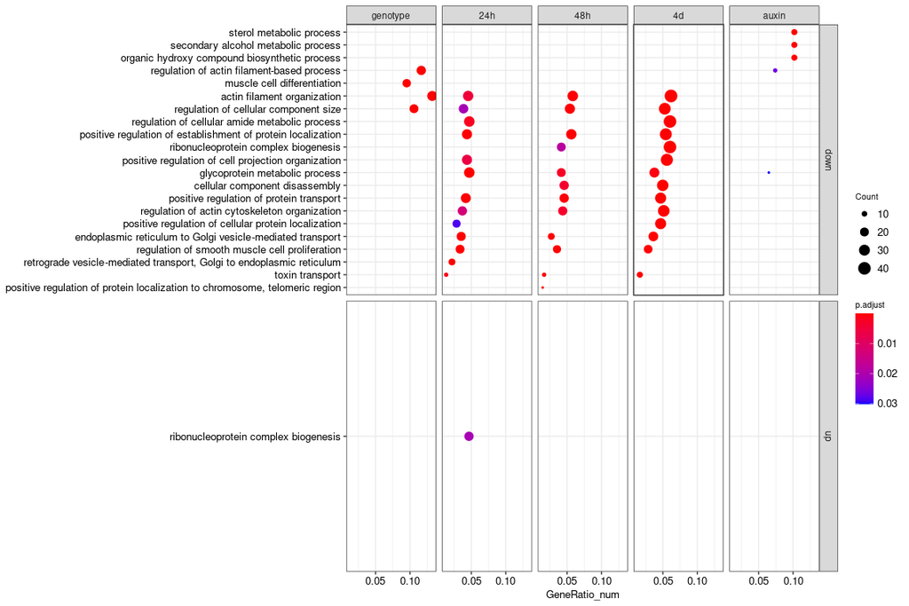

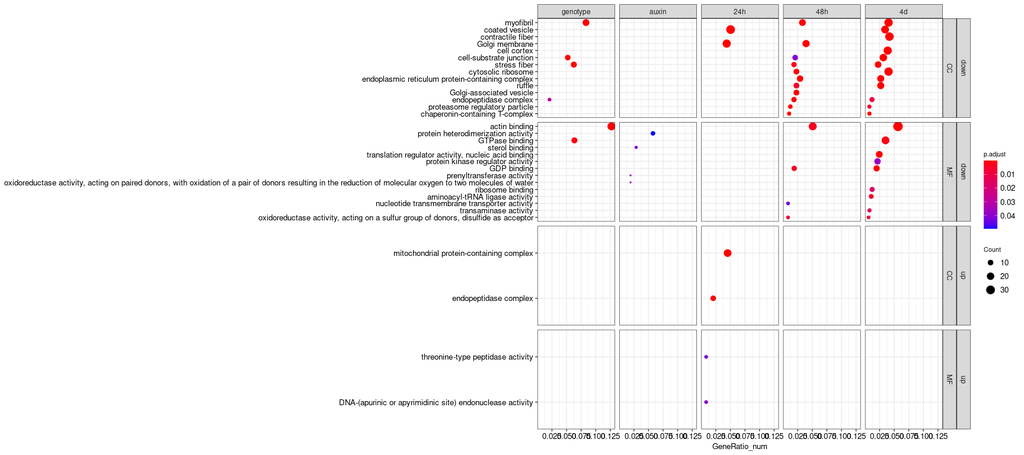

### 4.4.3 MSigDb Set Enrichment Test